# Analisi dades daily

Laura Guzman

1 novembre de 2019

```r
library(dplyr)
library(stats)
```

#Carreguem les dades

```r
#Carreguem datasets per a l'analisi
informations_households <-read.csv( file="C:/Users/Laura/Desktop/Smart meters London/workspace R/Dades netes/Analisi diari/informations_households.csv",header=TRUE, sep=",", stringsAsFactors = FALSE)
weather_d <-read.csv( file="C:/Users/Laura/Desktop/Smart meters London/workspace R/Dades netes/Analisi diari/weather_d.csv",header=TRUE, sep=",", stringsAsFactors = FALSE)
weather_holiday_season <-read.csv(file= "C:/Users/Laura/Desktop/Smart meters London/workspace R/Dades netes/Analisi diari/weather_holiday_season.csv" ,header=TRUE, sep=",", stringsAsFactors = FALSE)
daily<- read.csv( file="C:/Users/Laura/Desktop/Smart meters London/workspace R/Dades netes/Analisi diari/daily.csv" ,header=TRUE, sep=",", stringsAsFactors = FALSE)
daily_copia<-read.csv(file="C:/Users/Laura/Desktop/Smart meters London/workspace R/Dades netes/Analisi diari/daily_copia.csv" ,header=TRUE, sep=",", stringsAsFactors = FALSE)

informations_households_atributs <- read.csv(file="C:/Users/Laura/Desktop/Smart meters London/workspace R/Dades netes/Analisi diari/Informations_households_atributs.csv" ,header=TRUE, sep=",", stringsAsFactors = FALSE)
```

```r
#daily$weekday<- weekdays(daily$date)
library(lubridate)
daily$weekday<-wday(daily$date, week_start = getOption("lubridate.week.start", 1))
```

#Estadistics

Basics

```r
str(daily_copia)
```

```
## 'data.frame':    3510403 obs. of  16 variables:
##  $ X            : int  1 2 3 4 5 6 7 8 9 10 ...
##  $ LCLid        : chr  "MAC000152" "MAC000153" "MAC000156" "MAC000147" ...
##  $ date         : chr  "2011-11-23" "2011-11-23" "2011-11-23" "2011-11-23" ...
##  $ energy_median: num  0.172 0.676 0.275 0.075 0.174 ...
##  $ energy_mean  : num  0.249 0.904 0.296 0.108 0.252 ...
##  $ energy_max   : num  0.798 2.407 0.512 0.315 0.999 ...
##  $ energy_count : int  24 24 22 28 23 30 28 28 22 28 ...
##  $ energy_std   : num  0.194 0.5923 0.108 0.0717 0.2192 ...
##  $ energy_sum   : num  5.97 21.7 6.52 3.04 5.8 ...
##  $ energy_min   : num  0.055 0.261 0.162 0.033 0.098 0.094 0.008 0 0.11 0.059 ...
##  $ holidayType  : chr  "No Holiday" "No Holiday" "No Holiday" "No Holiday" ...
##  $ isHoliday    : logi  FALSE FALSE FALSE FALSE FALSE FALSE ...
##  $ season       : chr  "autumn" "autumn" "autumn" "autumn" ...
##  $ stdorToU     : chr  "Std" "Std" "Std" "ToU" ...
##  $ Acorn        : chr  "ACORN-E" "ACORN-E" "ACORN-F" "ACORN-F" ...
##  $ Acorn_grouped: chr  "Affluent" "Affluent" "Comfortable" "Comfortable" ...
```

Com que hem hagut de tornat a carregar el fitxer, primer modifiquem les variables que no estan en el seu tipus correcte:

```r
daily_copia$date <- as.Date(daily_copia$date)
daily_copia$holidayType <- as.factor(daily_copia$holidayType)
daily_copia$isHoliday <- as.factor(daily_copia$isHoliday )
daily_copia$season <- as.factor(daily_copia$season)
daily_copia$stdorToU <- as.factor(daily_copia$stdorToU)
daily_copia$Acorn <- as.factor(daily_copia$Acorn)
daily_copia$Acorn_grouped <- as.factor(daily_copia$Acorn_grouped)

daily_copia<-select(daily_copia,-X)

str(daily_copia)
```

```
## 'data.frame':    3510403 obs. of  15 variables:
##  $ LCLid        : chr  "MAC000152" "MAC000153" "MAC000156" "MAC000147" ...
##  $ date         : Date, format: "2011-11-23" "2011-11-23" ...
##  $ energy_median: num  0.172 0.676 0.275 0.075 0.174 ...
##  $ energy_mean  : num  0.249 0.904 0.296 0.108 0.252 ...
##  $ energy_max   : num  0.798 2.407 0.512 0.315 0.999 ...
##  $ energy_count : int  24 24 22 28 23 30 28 28 22 28 ...
##  $ energy_std   : num  0.194 0.5923 0.108 0.0717 0.2192 ...
##  $ energy_sum   : num  5.97 21.7 6.52 3.04 5.8 ...
##  $ energy_min   : num  0.055 0.261 0.162 0.033 0.098 0.094 0.008 0 0.11 0.059 ...
##  $ holidayType  : Factor w/ 10 levels "Boxing Day","Christmas Day",..: 7 7 7 7 7 7 7 7 7 7 ...
##  $ isHoliday    : Factor w/ 2 levels "FALSE","TRUE": 1 1 1 1 1 1 1 1 1 1 ...
##  $ season       : Factor w/ 4 levels "autumn","spring",..: 1 1 1 1 1 1 1 1 1 1 ...
##  $ stdorToU     : Factor w/ 2 levels "Std","ToU": 1 1 1 2 1 1 1 1 1 1 ...
##  $ Acorn        : Factor w/ 18 levels "ACORN-A","ACORN-B",..: 5 5 6 6 17 6 6 6 4 5 ...
##  $ Acorn_grouped: Factor w/ 3 levels "Adversity","Affluent",..: 2 2 3 3 1 3 3 3 2 2 ...
```

```r
str(informations_households)
```

```
## 'data.frame':    5566 obs. of  6 variables:
##  $ X            : int  1 2 3 4 5 6 7 8 9 10 ...
##  $ LCLid        : chr  "MAC005492" "MAC001074" "MAC000002" "MAC003613" ...
##  $ stdorToU     : chr  "ToU" "ToU" "Std" "Std" ...
##  $ Acorn        : chr  "ACORN-A" "ACORN-A" "ACORN-A" "ACORN-A" ...
##  $ Acorn_grouped: chr  "Affluent" "Affluent" "Affluent" "Affluent" ...
##  $ file         : chr  "block_0" "block_0" "block_0" "block_0" ...
```

```r
informations_households$stdorToU <- as.factor(informations_households$stdorToU)
informations_households$Acorn <- as.factor(informations_households$Acorn)
informations_households$Acorn_grouped <- as.factor(informations_households$Acorn_grouped)

informations_households<-select(informations_households,-X)


str(informations_households)
```

```
## 'data.frame':    5566 obs. of  5 variables:
##  $ LCLid        : chr  "MAC005492" "MAC001074" "MAC000002" "MAC003613" ...
##  $ stdorToU     : Factor w/ 2 levels "Std","ToU": 2 2 1 1 1 1 1 1 1 1 ...
##  $ Acorn        : Factor w/ 18 levels "ACORN-A","ACORN-B",..: 1 1 1 1 1 1 1 1 1 1 ...
##  $ Acorn_grouped: Factor w/ 3 levels "Adversity","Affluent",..: 2 2 2 2 2 2 2 2 2 2 ...
##  $ file         : chr  "block_0" "block_0" "block_0" "block_0" ...
```

```r
str(weather_holiday_season)
```

```
## 'data.frame':    829 obs. of  39 variables:
##  $ X                          : int  23 24 25 26 27 28 29 30 31 32 ...
##  $ temperatureMax             : num  10.4 12.9 13 13 13.5 ...
##  $ temperatureMaxHour         : int  14 12 5 14 10 23 14 12 7 23 ...
##  $ temperatureMin             : num  3.81 8.56 7.46 7.01 4.47 1.31 6.37 6.34 6.08 2.56 ...
##  $ temperatureMinHour         : int  7 2 23 1 23 5 23 0 23 7 ...
##  $ apparentTemperatureMax     : num  10.4 12.9 13 13 13.5 ...
##  $ apparentTemperatureMaxHour : int  14 12 5 14 10 23 14 12 7 12 ...
##  $ apparentTemperatureMin     : num  2.18 7.01 4.84 4.69 2.94 1.31 3.39 3.34 5.29 0.46 ...
##  $ apparentTemperatureMinHour : int  7 2 23 5 23 5 23 1 23 7 ...
##  $ temperatureHigh            : num  10.4 12.9 12.3 13 13.5 ...
##  $ temperatureHighHour        : int  14 12 12 14 10 19 14 12 7 12 ...
##  $ temperatureLow             : num  8.24 9.71 7.01 11.59 1.31 ...
##  $ temperatureLowHour         : int  22 19 1 23 5 19 0 0 7 19 ...
##  $ apparentTemperatureHigh    : num  10.4 12.9 12.3 13 13.5 ...
```

[output cut: 25 more lines]

```r
weather_holiday_season$icon <- as.factor(weather_holiday_season$icon)
weather_holiday_season$precipType <- as.factor(weather_holiday_season$precipType)
weather_holiday_season$summary <- as.factor(weather_holiday_season$summary)
weather_holiday_season$year <- as.factor(weather_holiday_season$year)
weather_holiday_season$month <- as.factor(weather_holiday_season$month)
weather_holiday_season$weekday <- as.factor(weather_holiday_season$weekday)
weather_holiday_season$holidayType <- as.factor(weather_holiday_season$holidayType)
weather_holiday_season$isHoliday <- as.factor(weather_holiday_season$isHoliday)
weather_holiday_season$season <- as.factor(weather_holiday_season$season)
weather_holiday_season$uvIndex <- as.factor(weather_holiday_season$uvIndex)
weather_holiday_season$sunsetTimeHour <- as.factor(weather_holiday_season$sunsetTimeHour)
weather_holiday_season$sunriseTimeHour <- as.factor(weather_holiday_season$sunriseTimeHour)
weather_holiday_season$date <- as.Date(weather_holiday_season$date)

weather_holiday_season<-select(weather_holiday_season,-X)


str(weather_holiday_season)
```

```
## 'data.frame':    829 obs. of  38 variables:
##  $ temperatureMax             : num  10.4 12.9 13 13 13.5 ...
##  $ temperatureMaxHour         : int  14 12 5 14 10 23 14 12 7 23 ...
##  $ temperatureMin             : num  3.81 8.56 7.46 7.01 4.47 1.31 6.37 6.34 6.08 2.56 ...
##  $ temperatureMinHour         : int  7 2 23 1 23 5 23 0 23 7 ...
##  $ apparentTemperatureMax     : num  10.4 12.9 13 13 13.5 ...
##  $ apparentTemperatureMaxHour : int  14 12 5 14 10 23 14 12 7 12 ...
##  $ apparentTemperatureMin     : num  2.18 7.01 4.84 4.69 2.94 1.31 3.39 3.34 5.29 0.46 ...
##  $ apparentTemperatureMinHour : int  7 2 23 5 23 5 23 1 23 7 ...
##  $ temperatureHigh            : num  10.4 12.9 12.3 13 13.5 ...
##  $ temperatureHighHour        : int  14 12 12 14 10 19 14 12 7 12 ...
##  $ temperatureLow             : num  8.24 9.71 7.01 11.59 1.31 ...
##  $ temperatureLowHour         : int  22 19 1 23 5 19 0 0 7 19 ...
##  $ apparentTemperatureHigh    : num  10.4 12.9 12.3 13 13.5 ...
##  $ apparentTemperatureHighHour: int  14 12 12 14 10 19 14 12 7 12 ...
```

[output cut: 24 more lines]

```r
str(weather_d)
```

```
## 'data.frame':    882 obs. of  36 variables:
##  $ X                          : int  14 61 35 32 47 27 36 11 34 33 ...
##  $ temperatureMax             : num  15.6 15.2 17.4 15.5 13.9 ...
##  $ temperatureMaxHour         : int  15 23 14 11 15 14 13 0 13 15 ...
##  $ temperatureMin             : num  9.68 8.88 12.79 11.53 10.17 ...
##  $ temperatureMinHour         : int  22 3 21 23 2 5 0 9 0 4 ...
##  $ apparentTemperatureMax     : num  15.6 15.2 17.4 15.5 13.9 ...
##  $ apparentTemperatureMaxHour : int  15 23 14 11 15 14 13 0 13 15 ...
##  $ apparentTemperatureMin     : num  9.01 7.33 12.79 11.53 10.17 ...
##  $ apparentTemperatureMinHour : int  22 3 21 23 2 6 0 8 0 4 ...
##  $ temperatureHigh            : num  15.6 15.1 17.4 15.5 13.9 ...
##  $ temperatureHighHour        : int  15 13 14 11 15 14 13 16 13 15 ...
##  $ temperatureLow             : num  8.88 13.99 12.52 10.17 9.46 ...
##  $ temperatureLowHour         : int  3 19 7 2 5 0 8 21 4 7 ...
##  $ apparentTemperatureHigh    : num  15.6 15.1 17.4 15.5 13.9 ...
```

[output cut: 22 more lines]

```r
str(daily)
```

```
## 'data.frame':    3517002 obs. of  51 variables:
##  $ X                          : int  1 2 3 4 5 6 7 8 9 10 ...
##  $ LCLid                      : chr  "MAC000152" "MAC000153" "MAC000156" "MAC000147" ...
##  $ date                       : chr  "2011-11-23" "2011-11-23" "2011-11-23" "2011-11-23" ...
##  $ energy_median              : num  0.172 0.676 0.275 0.075 0.174 ...
##  $ energy_mean                : num  0.249 0.904 0.296 0.108 0.252 ...
##  $ energy_max                 : num  0.798 2.407 0.512 0.315 0.999 ...
##  $ energy_count               : int  24 24 22 28 23 30 28 28 22 28 ...
##  $ energy_sum                 : num  5.97 21.7 6.52 3.04 5.8 ...
##  $ energy_min                 : num  0.055 0.261 0.162 0.033 0.098 0.094 0.008 0 0.11 0.059 ...
##  $ holidayType                : chr  "No Holiday" "No Holiday" "No Holiday" "No Holiday" ...
##  $ isHoliday                  : logi  FALSE FALSE FALSE FALSE FALSE FALSE ...
##  $ season                     : chr  "autumn" "autumn" "autumn" "autumn" ...
##  $ stdorToU                   : chr  "Std" "Std" "Std" "ToU" ...
##  $ Acorn                      : chr  "ACORN-E" "ACORN-E" "ACORN-F" "ACORN-F" ...
```

[output cut: 37 more lines]

```r
weather_d$icon <- as.factor(weather_d$icon)
weather_d$precipType <- as.factor(weather_d$precipType)
weather_d$summary <- as.factor(weather_d$summary)
weather_d$year <- as.factor(weather_d$year)
weather_d$month <- as.factor(weather_d$month)
weather_d$weekday <- as.factor(weather_d$weekday)
weather_d$uvIndex <- as.factor(weather_d$uvIndex)
weather_d$sunsetTimeHour <- as.factor(weather_d$sunsetTimeHour)
weather_d$sunriseTimeHour <- as.factor(weather_d$sunriseTimeHour)
weather_d$date <- as.Date(weather_d$day)


daily$icon <- as.factor(daily$icon)
daily$precipType <- as.factor(daily$precipType)
daily$summary <- as.factor(daily$summary)
daily$year <- as.factor(daily$year)
daily$month <- as.factor(daily$month)
daily$weekday <- as.factor(daily$weekday)
daily$holidayType <- as.factor(daily$holidayType)
daily$isHoliday <- as.factor(daily$isHoliday)
daily$season <- as.factor(daily$season)
daily$uvIndex <- as.factor(daily$uvIndex)
daily$sunsetTimeHour <- as.factor(daily$sunsetTimeHour)
daily$sunriseTimeHour <- as.factor(daily$sunriseTimeHour)
daily$date <- as.Date(daily$date)
daily$tempMaxFactor <- as.factor(daily$tempMaxFactor)

daily$stdorToU <- as.factor(daily$stdorToU)
daily$Acorn <- as.factor(daily$Acorn)
daily$Acorn_grouped <- as.factor(daily$Acorn_grouped)

weather_d<-select(weather_d,-X)
daily<-select(daily,-X)


str(weather_d)
```

```
## 'data.frame':    882 obs. of  36 variables:
##  $ temperatureMax             : num  15.6 15.2 17.4 15.5 13.9 ...
##  $ temperatureMaxHour         : int  15 23 14 11 15 14 13 0 13 15 ...
##  $ temperatureMin             : num  9.68 8.88 12.79 11.53 10.17 ...
##  $ temperatureMinHour         : int  22 3 21 23 2 5 0 9 0 4 ...
##  $ apparentTemperatureMax     : num  15.6 15.2 17.4 15.5 13.9 ...
##  $ apparentTemperatureMaxHour : int  15 23 14 11 15 14 13 0 13 15 ...
##  $ apparentTemperatureMin     : num  9.01 7.33 12.79 11.53 10.17 ...
##  $ apparentTemperatureMinHour : int  22 3 21 23 2 6 0 8 0 4 ...
##  $ temperatureHigh            : num  15.6 15.1 17.4 15.5 13.9 ...
##  $ temperatureHighHour        : int  15 13 14 11 15 14 13 16 13 15 ...
##  $ temperatureLow             : num  8.88 13.99 12.52 10.17 9.46 ...
##  $ temperatureLowHour         : int  3 19 7 2 5 0 8 21 4 7 ...
##  $ apparentTemperatureHigh    : num  15.6 15.1 17.4 15.5 13.9 ...
##  $ apparentTemperatureHighHour: int  15 13 14 11 15 14 13 16 13 15 ...
```

[output cut: 22 more lines]

```r
str(daily)
```

```
## 'data.frame':    3517002 obs. of  50 variables:
##  $ LCLid                      : chr  "MAC000152" "MAC000153" "MAC000156" "MAC000147" ...
##  $ date                       : Date, format: "2011-11-23" "2011-11-23" ...
##  $ energy_median              : num  0.172 0.676 0.275 0.075 0.174 ...
##  $ energy_mean                : num  0.249 0.904 0.296 0.108 0.252 ...
##  $ energy_max                 : num  0.798 2.407 0.512 0.315 0.999 ...
##  $ energy_count               : int  24 24 22 28 23 30 28 28 22 28 ...
##  $ energy_sum                 : num  5.97 21.7 6.52 3.04 5.8 ...
##  $ energy_min                 : num  0.055 0.261 0.162 0.033 0.098 0.094 0.008 0 0.11 0.059 ...
##  $ holidayType                : Factor w/ 10 levels "Boxing Day","Christmas Day",..: 7 7 7 7 7 7 7 7 7 7 ...
##  $ isHoliday                  : Factor w/ 2 levels "FALSE","TRUE": 1 1 1 1 1 1 1 1 1 1 ...
##  $ season                     : Factor w/ 4 levels "autumn","spring",..: 1 1 1 1 1 1 1 1 1 1 ...
##  $ stdorToU                   : Factor w/ 2 levels "Std","ToU": 1 1 1 2 1 1 1 1 1 1 ...
##  $ Acorn                      : Factor w/ 18 levels "ACORN-A","ACORN-B",..: 5 5 6 6 17 6 6 6 4 5 ...
##  $ Acorn_grouped              : Factor w/ 3 levels "Adversity","Affluent",..: 2 2 3 3 1 3 3 3 2 2 ...
```

[output cut: 36 more lines]

```r
str(informations_households_atributs)
```

```
## 'data.frame':    5566 obs. of  5 variables:
##  $ X            : int  1 2 3 4 5 6 7 8 9 10 ...
##  $ LCLid        : chr  "MAC005492" "MAC001074" "MAC000002" "MAC003613" ...
##  $ stdorToU     : chr  "ToU" "ToU" "Std" "Std" ...
##  $ Acorn        : chr  "ACORN-A" "ACORN-A" "ACORN-A" "ACORN-A" ...
##  $ Acorn_grouped: chr  "Affluent" "Affluent" "Affluent" "Affluent" ...
```

```r
informations_households_atributs$stdorToU <- as.factor(informations_households_atributs$stdorToU)
informations_households_atributs$Acorn <- as.factor(informations_households_atributs$Acorn)
informations_households_atributs$Acorn_grouped <- as.factor(informations_households_atributs$Acorn_grouped)

informations_households_atributs<-select(informations_households_atributs,-X)


str(informations_households_atributs)
```

```
## 'data.frame':    5566 obs. of  4 variables:
##  $ LCLid        : chr  "MAC005492" "MAC001074" "MAC000002" "MAC003613" ...
##  $ stdorToU     : Factor w/ 2 levels "Std","ToU": 2 2 1 1 1 1 1 1 1 1 ...
##  $ Acorn        : Factor w/ 18 levels "ACORN-A","ACORN-B",..: 1 1 1 1 1 1 1 1 1 1 ...
##  $ Acorn_grouped: Factor w/ 3 levels "Adversity","Affluent",..: 2 2 2 2 2 2 2 2 2 2 ...
```

Qualitatiu

```r
library(knitr)
kable(summary(daily_copia)[,1:2],digits=2, align='l', caption="Estad??stica descriptiva de variables qualitatives consum diari")
```

Estad??stica descriptiva de variables qualitatives consum diari

|  | LCLid | date |
| --- | --- | --- |
|  | Length:3510403 | Min. :2011-11-23 |
|  | Class :character | 1st Qu.:2012-10-21 |
|  | Mode :character | Median :2013-03-30 |
|  | NA | Mean :2013-03-27 |
|  | NA | 3rd Qu.:2013-09-10 |
|  | NA | Max. :2014-02-28 |
|  | NA | NA |

```r
kable(summary(daily_copia)[,10:12],digits=2, align='l', caption="Estad??stica descriptiva de variables qualitatives consum diari")
```

Estad??stica descriptiva de variables qualitatives consum diari

|  | holidayType | isHoliday | season |
| --- | --- | --- | --- |
|  | No Holiday :3429773 | FALSE:3429773 | autumn:956149 |
|  | New Years Day : 11202 | TRUE : 80630 | spring:733592 |
|  | Christmas Day : 10618 | NA | summer:925246 |
|  | Boxing Day : 10616 | NA | winter:895416 |
|  | Easter Monday : 10276 | NA | NA |
|  | Summer bank holiday: 10011 | NA | NA |
|  | (Other) : 27907 | NA | NA |

```r
kable(summary(informations_households_atributs)[,1:4],digits=2, align='l', caption="Estad??stica descriptiva de variables qualitatives llars")
```

Estad??stica descriptiva de variables qualitatives llars

|  | LCLid | stdorToU | Acorn | Acorn_grouped |
| --- | --- | --- | --- | --- |
|  | Length:5566 | Std:4443 | ACORN-E:1567 | Adversity :1865 |
|  | Class :character | ToU:1123 | ACORN-Q: 831 | Affluent :2194 |
|  | Mode :character | NA | ACORN-F: 684 | Comfortable:1507 |
|  | NA | NA | ACORN-H: 455 | NA |
|  | NA | NA | ACORN-L: 342 | NA |
|  | NA | NA | ACORN-D: 292 | NA |
|  | NA | NA | (Other):1395 | NA |

```r
kable(summary(weather_holiday_season)[,25:27],digits=2, align='l', caption="Estad??stica descriptiva de variables qualitatives temps diari")
```

Estad??stica descriptiva de variables qualitatives temps diari

|  | icon | precipType | summary |
| --- | --- | --- | --- |
|  | clear-day : 5 | rain:809 | Mostly cloudy throughout the day. :167 |
|  | cloudy : 8 | snow: 20 | Partly cloudy throughout the day. :167 |
|  | fog : 69 | NA | Partly cloudy until evening. :130 |
|  | partly-cloudy-day :594 | NA | Mostly cloudy until evening. :111 |
|  | partly-cloudy-night: 31 | NA | Foggy in the morning. : 36 |
|  | wind :122 | NA | Partly cloudy starting in the afternoon, continuing until evening.: 16 |
|  | NA | NA | (Other) :202 |

```r
kable(summary(weather_holiday_season)[,36:38],digits=2, align='l', caption="Estad??stica descriptiva de variables qualitatives temps diari")
```

Estad??stica descriptiva de variables qualitatives temps diari

|  | holidayType | isHoliday | season |
| --- | --- | --- | --- |
|  | No Holiday :811 | FALSE:811 | autumn:207 |
|  | New Years Day : 3 | TRUE : 18 | spring:188 |
|  | Boxing Day : 2 | NA | summer:186 |
|  | Christmas Day : 2 | NA | winter:248 |
|  | Early May bank holiday: 2 | NA | NA |
|  | Easter Monday : 2 | NA | NA |
|  | (Other) : 7 | NA | NA |

Quantitatiu

```r
kable(summary(daily_copia)[,3:9],digits=2, align='l', caption="Estad??stica descriptiva de variables quantitatives consum diari")
```

Estad??stica descriptiva de variables quantitatives consum diari

|  | energy_median | energy_mean | energy_max | energy_count | energy_std | energy_sum | energy_min |
| --- | --- | --- | --- | --- | --- | --- | --- |
|  | Min. :0.0000 | Min. :0.00000 | Min. : 0.0000 | Min. : 1.0 | Min. :0.000 | Min. : 0.000 | Min. :0.00000 |
|  | 1st Qu.:0.0670 | 1st Qu.:0.09808 | 1st Qu.: 0.3460 | 1st Qu.:48.0 | 1st Qu.:0.069 | 1st Qu.: 4.682 | 1st Qu.:0.02000 |
|  | Median :0.1145 | Median :0.16329 | Median : 0.6880 | Median :48.0 | Median :0.133 | Median : 7.815 | Median :0.03900 |
|  | Mean :0.1587 | Mean :0.21173 | Mean : 0.8345 | Mean :47.8 | Mean :0.173 | Mean : 10.124 | Mean :0.05963 |
|  | 3rd Qu.:0.1910 | 3rd Qu.:0.26246 | 3rd Qu.: 1.1280 | 3rd Qu.:48.0 | 3rd Qu.:0.229 | 3rd Qu.: 12.569 | 3rd Qu.:0.07100 |
|  | Max. :6.9705 | Max. :6.92825 | Max. :10.7610 | Max. :48.0 | Max. :4.025 | Max. :332.556 | Max. :6.52400 |
|  | NA | NA | NA | NA | NA’s :11301 | NA | NA |

```r
kable(summary(weather_d)[,1:24],digits=2, align='l', caption="Estad??stica descriptiva de variables quantitatives temps diari")
```

Estad??stica descriptiva de variables quantitatives temps diari

|  | temperatureMax | temperatureMaxHour | temperatureMin | temperatureMinHour | apparentTemperatureMax | apparentTemperatureMaxHour | apparentTemperatureMin | apparentTemperatureMinHour | temperatureHigh | temperatureHighHour | temperatureLow | temperatureLowHour | apparentTemperatureHigh | apparentTemperatureHighHour | apparentTemperatureLow | apparentTemperatureLowHour | windBearing | dewPoint | cloudCover | windSpeed | pressure | humidity | visibility | moonPhase |
| --- | --- | --- | --- | --- | --- | --- | --- | --- | --- | --- | --- | --- | --- | --- | --- | --- | --- | --- | --- | --- | --- | --- | --- | --- |
|  | Min. :-0.060 | Min. : 0.00 | Min. :-5.640 | Min. : 0.000 | Min. :-4.110 | Min. : 0.00 | Min. :-8.880 | Min. : 0.000 | Min. :-0.810 | Min. : 6.00 | Min. :-5.64 | Min. : 0.000 | Min. :-6.460 | Min. : 7.0 | Min. :-8.880 | Min. : 0.000 | Min. : 0.0 | Min. :-7.84 | Min. :0.0000 | Min. :0.200 | Min. : 979.2 | Min. :0.4300 | Min. : 1.48 | Min. :0.0000 |
|  | 1st Qu.: 9.502 | 1st Qu.:13.00 | 1st Qu.: 3.705 | 1st Qu.: 4.000 | 1st Qu.: 7.332 | 1st Qu.:13.00 | 1st Qu.: 1.105 | 1st Qu.: 4.000 | 1st Qu.: 9.213 | 1st Qu.:13.00 | 1st Qu.: 3.99 | 1st Qu.: 4.000 | 1st Qu.: 7.032 | 1st Qu.:13.0 | 1st Qu.: 1.522 | 1st Qu.: 4.000 | 1st Qu.:120.5 | 1st Qu.: 3.18 | 1st Qu.:0.3500 | 1st Qu.:2.370 | 1st Qu.:1007.4 | 1st Qu.:0.7200 | 1st Qu.:10.33 | 1st Qu.:0.2600 |
|  | Median :12.625 | Median :14.00 | Median : 7.100 | Median : 6.000 | Median :12.625 | Median :14.00 | Median : 4.885 | Median : 5.500 | Median :12.470 | Median :14.00 | Median : 7.54 | Median : 5.000 | Median :12.470 | Median :14.0 | Median : 5.315 | Median : 5.000 | Median :219.0 | Median : 6.38 | Median :0.4700 | Median :3.440 | Median :1014.6 | Median :0.7900 | Median :11.97 | Median :0.5000 |
|  | Mean :13.660 | Mean :13.79 | Mean : 7.414 | Mean : 9.141 | Mean :12.929 | Mean :13.73 | Mean : 5.738 | Mean : 8.684 | Mean :13.542 | Mean :14.18 | Mean : 7.71 | Mean : 6.531 | Mean :12.724 | Mean :14.2 | Mean : 6.085 | Mean : 7.061 | Mean :195.7 | Mean : 6.53 | Mean :0.4778 | Mean :3.582 | Mean :1014.1 | Mean :0.7819 | Mean :11.17 | Mean :0.5009 |
|  | 3rd Qu.:17.920 | 3rd Qu.:15.00 | 3rd Qu.:11.277 | 3rd Qu.:18.000 | 3rd Qu.:17.920 | 3rd Qu.:16.00 | 3rd Qu.:11.277 | 3rd Qu.:10.000 | 3rd Qu.:17.910 | 3rd Qu.:15.00 | 3rd Qu.:11.47 | 3rd Qu.: 7.000 | 3rd Qu.:17.910 | 3rd Qu.:16.0 | 3rd Qu.:11.467 | 3rd Qu.: 7.000 | 3rd Qu.:255.0 | 3rd Qu.:10.06 | 3rd Qu.:0.6000 | 3rd Qu.:4.577 | 3rd Qu.:1021.8 | 3rd Qu.:0.8600 | 3rd Qu.:12.83 | 3rd Qu.:0.7500 |
|  | Max. :32.400 | Max. :23.00 | Max. :20.540 | Max. :23.000 | Max. :32.420 | Max. :23.00 | Max. :20.540 | Max. :23.000 | Max. :32.400 | Max. :19.00 | Max. :20.54 | Max. :23.000 | Max. :32.420 | Max. :19.0 | Max. :20.540 | Max. :23.000 | Max. :359.0 | Max. :17.77 | Max. :1.0000 | Max. :9.960 | Max. :1040.9 | Max. :0.9800 | Max. :15.34 | Max. :0.9900 |
|  | NA | NA | NA | NA | NA | NA | NA | NA | NA | NA | NA | NA | NA | NA | NA | NA | NA | NA | NA | NA | NA | NA | NA | NA |

#Correlacions

```r
weather_holiday_season$uvIndex<-as.integer(weather_holiday_season$uvIndex)
weather_holiday_season$sunsetTimeHour<-as.integer(weather_holiday_season$sunsetTimeHour)
weather_holiday_season$sunriseTimeHour<-as.integer(weather_holiday_season$sunriseTimeHour)
```

```r
str(weather_holiday_season)
```

```
## 'data.frame':    829 obs. of  38 variables:
##  $ temperatureMax             : num  10.4 12.9 13 13 13.5 ...
##  $ temperatureMaxHour         : int  14 12 5 14 10 23 14 12 7 23 ...
##  $ temperatureMin             : num  3.81 8.56 7.46 7.01 4.47 1.31 6.37 6.34 6.08 2.56 ...
##  $ temperatureMinHour         : int  7 2 23 1 23 5 23 0 23 7 ...
##  $ apparentTemperatureMax     : num  10.4 12.9 13 13 13.5 ...
##  $ apparentTemperatureMaxHour : int  14 12 5 14 10 23 14 12 7 12 ...
##  $ apparentTemperatureMin     : num  2.18 7.01 4.84 4.69 2.94 1.31 3.39 3.34 5.29 0.46 ...
##  $ apparentTemperatureMinHour : int  7 2 23 5 23 5 23 1 23 7 ...
##  $ temperatureHigh            : num  10.4 12.9 12.3 13 13.5 ...
##  $ temperatureHighHour        : int  14 12 12 14 10 19 14 12 7 12 ...
##  $ temperatureLow             : num  8.24 9.71 7.01 11.59 1.31 ...
##  $ temperatureLowHour         : int  22 19 1 23 5 19 0 0 7 19 ...
##  $ apparentTemperatureHigh    : num  10.4 12.9 12.3 13 13.5 ...
##  $ apparentTemperatureHighHour: int  14 12 12 14 10 19 14 12 7 12 ...
```

[output cut: 24 more lines]

```r
#Correlacions amb les pròpies variables del temps:

corrrr<-cor(weather_holiday_season[,c(1:24,28:31)])
print(corrrr)
```

```
##                             temperatureMax temperatureMaxHour
## temperatureMax                 1.000000000        0.143608517
## temperatureMaxHour             0.143608517        1.000000000
## temperatureMin                 0.895540132        0.088567442
## temperatureMinHour            -0.218002847       -0.358708601
## apparentTemperatureMax         0.989650286        0.138885376
## apparentTemperatureMaxHour     0.154391763        0.748265244
## apparentTemperatureMin         0.910840987        0.111666629
## apparentTemperatureMinHour    -0.182212205       -0.338305747
## temperatureHigh                0.997843001        0.153510160
## temperatureHighHour            0.090492091        0.564668186
## temperatureLow                 0.882254345        0.216570700
## temperatureLowHour            -0.220591633       -0.001721702
## apparentTemperatureHigh        0.986204685        0.149690162
## apparentTemperatureHighHour    0.078396487        0.495457761
## apparentTemperatureLow         0.894596319        0.218165355
## apparentTemperatureLowHour    -0.275496271        0.010708407
## windBearing                    0.064484353       -0.034600216
## dewPoint                       0.864943611        0.101846348
## cloudCover                    -0.333615444       -0.018261245
## windSpeed                     -0.154118225       -0.132982627
## pressure                       0.119506266        0.198484108
## humidity                      -0.405068266       -0.038631948
## visibility                     0.259293749       -0.056698307
## moonPhase                      0.004389378       -0.033866255
## uvIndex                        0.696539238        0.167558449
## uvIndexHour                    0.224032313        0.045860495
## sunsetTimeHour                 0.663748781        0.185157966
## sunriseTimeHour               -0.678764648       -0.180874241
##                             temperatureMin temperatureMinHour
## temperatureMax                 0.895540132       -0.218002847
## temperatureMaxHour             0.088567442       -0.358708601
## temperatureMin                 1.000000000       -0.102977767
## temperatureMinHour            -0.102977767        1.000000000
## apparentTemperatureMax         0.890915931       -0.203452919
## apparentTemperatureMaxHour     0.091769812       -0.349816994
## apparentTemperatureMin         0.982444431       -0.123101086
## apparentTemperatureMinHour    -0.086416551        0.790772304
## temperatureHigh                0.894656547       -0.225672748
## temperatureHighHour            0.033831945       -0.312028685
```

[output cut: 380 more lines]

```
## apparentTemperatureHighHour   0.1780062330     -0.16269641
## apparentTemperatureLow        0.5938679646     -0.61780001
## apparentTemperatureLowHour   -0.3134408446      0.32455973
## windBearing                  -0.1312597856      0.12086313
## dewPoint                      0.4814841324     -0.51389470
## cloudCover                   -0.1179952043      0.14179109
## windSpeed                    -0.1445666020      0.15674048
## pressure                      0.0965519888     -0.07382443
## humidity                     -0.4965867723      0.46737129
## visibility                    0.1901315563     -0.18306759
## moonPhase                     0.0005190737     -0.01180649
## uvIndex                       0.9210572674     -0.91971873
## uvIndexHour                   0.3949363284     -0.39422152
## sunsetTimeHour                1.0000000000     -0.94190552
## sunriseTimeHour              -0.9419055169      1.00000000
```

```r
daily$uvIndex <- as.integer(daily$uvIndex)
daily$sunsetTimeHour <- as.integer(daily$sunsetTimeHour)
daily$sunriseTimeHour  <- as.integer(daily$sunriseTimeHour)
daily$year <- as.integer(daily$year)
daily$month  <- as.integer(daily$month)
daily$weekday  <- as.integer(daily$weekday)


cor(daily[,c(4,5,7, 15:38, 42:48)])
```

```
##                              energy_mean   energy_max  energy_sum
## energy_mean                  1.000000000  0.763127734  0.99380858
## energy_max                   0.763127734  1.000000000  0.76561052
## energy_sum                   0.993808578  0.765610523  1.00000000
## temperatureMax              -0.170978975 -0.153866076 -0.16972760
## temperatureMaxHour          -0.031651488 -0.027196745 -0.03143090
## temperatureMin              -0.163035197 -0.148550197 -0.16198214
## temperatureMinHour           0.038866105  0.036125973  0.04015359
## apparentTemperatureMax      -0.171334526 -0.152435000 -0.16991841
## apparentTemperatureMaxHour  -0.031868663 -0.026940015 -0.03198094
## apparentTemperatureMin      -0.166904403 -0.151019189 -0.16600117
## apparentTemperatureMinHour   0.033702404  0.031206909  0.03498388
## temperatureHigh             -0.171318543 -0.153855600 -0.17010217
## temperatureHighHour         -0.015415657 -0.014445596 -0.01528542
## temperatureLow              -0.156344638 -0.141891477 -0.15502767
## temperatureLowHour           0.045196587  0.038291582  0.04495729
## apparentTemperatureHigh     -0.171878374 -0.152554077 -0.17057303
## apparentTemperatureHighHour -0.011512870 -0.010458734 -0.01081145
## apparentTemperatureLow      -0.160663867 -0.144922075 -0.15966543
## apparentTemperatureLowHour   0.055071291  0.048019006  0.05515233
## windBearing                 -0.015519608 -0.008904099 -0.01339324
## dewPoint                    -0.151239243 -0.137260570 -0.15034866
## cloudCover                   0.056215970  0.049699943  0.05521214
## windSpeed                    0.033785753  0.029155487  0.03506164
## pressure                    -0.039279104 -0.029448599 -0.03732787
## humidity                     0.080008927  0.070846751  0.07899837
## visibility                  -0.057737628 -0.053101443 -0.05754828
## moonPhase                   -0.007745961 -0.009252214 -0.01105808
## uvIndex                     -0.145061651 -0.126961166 -0.14487251
## uvIndexHour                 -0.058371773 -0.048932933 -0.05832960
## sunsetTimeHour              -0.147343507 -0.127464058 -0.14766966
## sunriseTimeHour              0.153725180  0.131573542  0.15424182
## year                         0.031476090  0.022355119  0.02967666
## month                       -0.037784671 -0.038716171 -0.03541238
## weekday                      0.017486617  0.012466346  0.01698481
##                             temperatureMax temperatureMaxHour
## energy_mean                    -0.17097898        -0.03165149
## energy_max                     -0.15386608        -0.02719675
## energy_sum                     -0.16972760        -0.03143090
## temperatureMax                  1.00000000         0.16233925
```

[output cut: 540 more lines]

```
## windBearing                  0.19985673  0.0290538222
## dewPoint                     0.33505049 -0.0456624873
## cloudCover                  -0.13431357 -0.0338690251
## windSpeed                   -0.12246239  0.0426106485
## pressure                     0.09213458  0.0270127545
## humidity                     0.17382328 -0.0378921886
## visibility                   0.07328250  0.0765646532
## moonPhase                    0.03152601 -0.0177350278
## uvIndex                     -0.12160039 -0.0044701369
## uvIndexHour                 -0.23195282  0.0105525882
## sunsetTimeHour              -0.22830677 -0.0006051533
## sunriseTimeHour              0.05953513 -0.0010961764
## year                        -0.48223977 -0.0011883860
## month                        1.00000000 -0.0012267997
## weekday                     -0.00122680  1.0000000000
```

Copiem les dades a excel i fem un headmap per veure clarament les relacions.

```r
cor(daily$temperatureMax,daily$energy_max)
```

```
## [1] -0.1538661
```

```r
cor(daily$temperatureMax,daily$energy_mean)
```

```
## [1] -0.170979
```

```r
cor(daily$temperatureMax,daily$energy_sum)
```

```
## [1] -0.1697276
```

```r
cor(daily$temperatureMax,daily$energy_min)
```

```
## [1] -0.05533401
```

```r
cor(daily$temperatureMin,daily$energy_max)
```

```
## [1] -0.1485502
```

```r
cor(daily$temperatureMin,daily$energy_mean)
```

```
## [1] -0.1630352
```

```r
cor(daily$temperatureMin,daily$energy_sum)
```

```
## [1] -0.1619821
```

```r
cor(daily$temperatureMin,daily$energy_min)
```

```
## [1] -0.05317994
```

```r
cor(daily$temperatureHigh,daily$energy_max)
```

```
## [1] -0.1538556
```

```r
cor(daily$temperatureHigh,daily$energy_mean)
```

```
## [1] -0.1713185
```

```r
cor(daily$temperatureHigh,daily$energy_sum)
```

```
## [1] -0.1701022
```

```r
cor(daily$temperatureHigh,daily$energy_min)
```

```
## [1] -0.05540741
```

```r
cor(daily$apparentTemperatureMax,daily$energy_max)
```

```
## [1] -0.152435
```

```r
cor(daily$apparentTemperatureMax,daily$energy_mean)
```

```
## [1] -0.1713345
```

```r
cor(daily$apparentTemperatureMax,daily$energy_sum)
```

```
## [1] -0.1699184
```

```r
cor(daily$apparentTemperatureMax,daily$energy_min)
```

```
## [1] -0.05745442
```

```r
#Temperatuta té alguna relació amb energy_max, mean and sum.
```

```r
cor(daily$windBearing,daily$energy_max)
```

```
## [1] -0.008904099
```

```r
cor(daily$dewPoint,daily$energy_mean)#-0.15
```

```
## [1] -0.1512392
```

```r
cor(daily$cloudCover,daily$energy_sum)#0.05
```

```
## [1] 0.05521214
```

```r
cor(daily$windSpeed,daily$energy_min)
```

```
## [1] 0.008835246
```

```r
cor(daily$pressure,daily$energy_max)
```

```
## [1] -0.0294486
```

```r
cor(daily$humidity,daily$energy_mean)#0.08
```

```
## [1] 0.08000893
```

```r
cor(daily$visibility,daily$energy_sum)#-0.05
```

```
## [1] -0.05754828
```

```r
cor(daily$moonPhase,daily$energy_min)
```

```
## [1] 0.001036199
```

```r
cor(daily$uvIndex,daily$energy_max)#-0.12
```

```
## [1] -0.1269612
```

```r
cor(daily$uvIndexHour,daily$energy_mean)#-0.05
```

```
## [1] -0.05837177
```

```r
cor(daily$sunsetTimeHour,daily$energy_sum)#-0.14
```

```
## [1] -0.1476697
```

```r
cor(daily$sunriseTimeHour,daily$energy_min)
```

```
## [1] 0.04654041
```

Qualitatives

```r
library(Hmisc)
print("holidayType")
```

```
## [1] "holidayType"
```

```r
rcorr(daily$energy_sum,daily$holidayType, type="pearson")
```

```
##       x     y
## x  1.00 -0.01
## y -0.01  1.00
##
## n= 3517002
##
##
## P
##   x  y
## x     0
## y  0
```

```r
rcorr(daily$energy_mean,daily$holidayType, type="pearson")
```

```
##       x     y
## x  1.00 -0.01
## y -0.01  1.00
##
## n= 3517002
##
##
## P
##   x  y
## x     0
## y  0
```

```r
rcorr(daily$energy_max,daily$holidayType, type="pearson")
```

```
##   x y
## x 1 0
## y 0 1
##
## n= 3517002
##
##
## P
##   x  y
## x     0
## y  0
```

```r
rcorr(daily$energy_min,daily$holidayType, type="pearson")
```

```
##       x     y
## x  1.00 -0.01
## y -0.01  1.00
##
## n= 3517002
##
##
## P
##   x  y
## x     0
## y  0
```

```r
print("isHoliday")
```

```
## [1] "isHoliday"
```

```r
rcorr(daily$energy_sum,daily$isHoliday, type="pearson")
```

```
##   x y
## x 1 0
## y 0 1
##
## n= 3517002
##
##
## P
##   x  y
## x     0
## y  0
```

```r
rcorr(daily$energy_mean,daily$isHoliday, type="pearson")
```

```
##   x y
## x 1 0
## y 0 1
##
## n= 3517002
##
##
## P
##   x  y
## x     0
## y  0
```

```r
rcorr(daily$energy_max,daily$isHoliday, type="pearson")
```

```
##   x y
## x 1 0
## y 0 1
##
## n= 3517002
##
##
## P
##   x  y
## x     0
## y  0
```

```r
rcorr(daily$energy_min,daily$isHoliday, type="pearson")
```

```
##   x y
## x 1 0
## y 0 1
##
## n= 3517002
##
##
## P
##   x  y
## x     0
## y  0
```

```r
print("season")
```

```
## [1] "season"
```

```r
rcorr(daily$energy_sum,daily$season, type="pearson")
```

```
##      x    y
## x 1.00 0.02
## y 0.02 1.00
##
## n= 3517002
##
##
## P
##   x  y
## x     0
## y  0
```

```r
rcorr(daily$energy_mean,daily$season, type="pearson")
```

```
##      x    y
## x 1.00 0.02
## y 0.02 1.00
##
## n= 3517002
##
##
## P
##   x  y
## x     0
## y  0
```

```r
rcorr(daily$energy_max,daily$season, type="pearson")
```

```
##      x    y
## x 1.00 0.01
## y 0.01 1.00
##
## n= 3517002
##
##
## P
##   x  y
## x     0
## y  0
```

```r
rcorr(daily$energy_min,daily$season, type="pearson")
```

```
##      x    y
## x 1.00 0.02
## y 0.02 1.00
##
## n= 3517002
##
##
## P
##   x  y
## x     0
## y  0
```

```r
print("icon")
```

```
## [1] "icon"
```

```r
rcorr(daily$energy_sum,daily$icon, type="pearson")
```

```
##      x    y
## x 1.00 0.01
## y 0.01 1.00
##
## n= 3517002
##
##
## P
##   x  y
## x     0
## y  0
```

```r
rcorr(daily$energy_mean,daily$icon, type="pearson")
```

```
##      x    y
## x 1.00 0.01
## y 0.01 1.00
##
## n= 3517002
##
##
## P
##   x  y
## x     0
## y  0
```

```r
rcorr(daily$energy_max,daily$icon, type="pearson")
```

```
##      x    y
## x 1.00 0.01
## y 0.01 1.00
##
## n= 3517002
##
##
## P
##   x  y
## x     0
## y  0
```

```r
rcorr(daily$energy_min,daily$icon, type="pearson")
```

```
##   x y
## x 1 0
## y 0 1
##
## n= 3517002
##
##
## P
##   x  y
## x     0
## y  0
```

```r
print("preciptype")
```

```
## [1] "preciptype"
```

```r
rcorr(daily$energy_sum,daily$precipType, type="pearson")
```

```
##      x    y
## x 1.00 0.05
## y 0.05 1.00
##
## n= 3517002
##
##
## P
##   x  y
## x     0
## y  0
```

```r
rcorr(daily$energy_mean,daily$precipType, type="pearson")
```

```
##      x    y
## x 1.00 0.06
## y 0.06 1.00
##
## n= 3517002
##
##
## P
##   x  y
## x     0
## y  0
```

```r
rcorr(daily$energy_max,daily$precipType, type="pearson")
```

```
##      x    y
## x 1.00 0.04
## y 0.04 1.00
##
## n= 3517002
##
##
## P
##   x  y
## x     0
## y  0
```

```r
rcorr(daily$energy_min,daily$precipType, type="pearson")
```

```
##      x    y
## x 1.00 0.03
## y 0.03 1.00
##
## n= 3517002
##
##
## P
##   x  y
## x     0
## y  0
```

```r
print("summary")
```

```
## [1] "summary"
```

```r
rcorr(daily$energy_sum,daily$summary, type="pearson")
```

```
##       x     y
## x  1.00 -0.05
## y -0.05  1.00
##
## n= 3517002
##
##
## P
##   x  y
## x     0
## y  0
```

```r
rcorr(daily$energy_mean,daily$summary, type="pearson")
```

```
##       x     y
## x  1.00 -0.05
## y -0.05  1.00
##
## n= 3517002
##
##
## P
##   x  y
## x     0
## y  0
```

```r
rcorr(daily$energy_max,daily$summary, type="pearson")
```

```
##       x     y
## x  1.00 -0.04
## y -0.04  1.00
##
## n= 3517002
##
##
## P
##   x  y
## x     0
## y  0
```

```r
rcorr(daily$energy_min,daily$summary, type="pearson")
```

```
##       x     y
## x  1.00 -0.01
## y -0.01  1.00
##
## n= 3517002
##
##
## P
##   x  y
## x     0
## y  0
```

```r
print("stdortou")
```

```
## [1] "stdortou"
```

```r
rcorr(daily$energy_max,daily$stdorToU, type="pearson")
```

```
##       x     y
## x  1.00 -0.03
## y -0.03  1.00
##
## n= 3517002
##
##
## P
##   x  y
## x     0
## y  0
```

```r
rcorr(daily$energy_mean,daily$stdorToU, type="pearson")
```

```
##       x     y
## x  1.00 -0.03
## y -0.03  1.00
##
## n= 3517002
##
##
## P
##   x  y
## x     0
## y  0
```

```r
rcorr(daily$energy_min,daily$stdorToU, type="pearson")
```

```
##       x     y
## x  1.00 -0.02
## y -0.02  1.00
##
## n= 3517002
##
##
## P
##   x  y
## x     0
## y  0
```

```r
rcorr(daily$energy_sum,daily$stdorToU, type="pearson")
```

```
##       x     y
## x  1.00 -0.03
## y -0.03  1.00
##
## n= 3517002
##
##
## P
##   x  y
## x     0
## y  0
```

```r
print("acorn grouped")
```

```
## [1] "acorn grouped"
```

```r
rcorr(daily$energy_sum,daily$Acorn_grouped, type="pearson")
```

```
##      x    y
## x 1.00 0.07
## y 0.07 1.00
##
## n= 3517002
##
##
## P
##   x  y
## x     0
## y  0
```

```r
rcorr(daily$energy_mean,daily$Acorn_grouped, type="pearson")
```

```
##      x    y
## x 1.00 0.07
## y 0.07 1.00
##
## n= 3517002
##
##
## P
##   x  y
## x     0
## y  0
```

```r
rcorr(daily$energy_max,daily$Acorn_grouped, type="pearson")
```

```
##      x    y
## x 1.00 0.05
## y 0.05 1.00
##
## n= 3517002
##
##
## P
##   x  y
## x     0
## y  0
```

```r
rcorr(daily$energy_min,daily$Acorn_grouped, type="pearson")
```

```
##      x    y
## x 1.00 0.05
## y 0.05 1.00
##
## n= 3517002
##
##
## P
##   x  y
## x     0
## y  0
```

```r
print("acorn")
```

```
## [1] "acorn"
```

```r
rcorr(daily$energy_sum,daily$Acorn, type="pearson")
```

```
##       x     y
## x  1.00 -0.16
## y -0.16  1.00
##
## n= 3517002
##
##
## P
##   x  y
## x     0
## y  0
```

```r
rcorr(daily$energy_mean,daily$Acorn, type="pearson")
```

```
##       x     y
## x  1.00 -0.16
## y -0.16  1.00
##
## n= 3517002
##
##
## P
##   x  y
## x     0
## y  0
```

```r
rcorr(daily$energy_max,daily$Acorn, type="pearson")
```

```
##       x     y
## x  1.00 -0.11
## y -0.11  1.00
##
## n= 3517002
##
##
## P
##   x  y
## x     0
## y  0
```

```r
rcorr(daily$energy_min,daily$Acorn, type="pearson")
```

```
##       x     y
## x  1.00 -0.13
## y -0.13  1.00
##
## n= 3517002
##
##
## P
##   x  y
## x     0
## y  0
```

```r
daily$uvIndex <- as.factor(daily$uvIndex)
daily$sunsetTimeHour <- as.factor(daily$sunsetTimeHour)
daily$sunriseTimeHour  <- as.factor(daily$sunriseTimeHour)
daily$year <- as.factor(daily$year)
daily$month  <- as.factor(daily$month)
daily$weekday  <- as.factor(daily$weekday)
```

#Contrast hipòtesis

##Consumidors Tou consumeixen menys que std? (4.2.1)

Hipòtesi nul·la: mitjana consum (energy_sum) dels consumidors std = mitjana energy_sum dels consumidors Tou. Hipòtesi alternativa: mitjana_energy_sum_std>mitjana_energy_sum_tou

```r
#Calculem grups:

grup_std<-daily$energy_sum[daily$stdorToU=="Std"]
grup_ToU<-daily$energy_sum[daily$stdorToU=="ToU"]
```

```r
#normalitat
library(nortest)
#Anderson-Darling normality test
ad.test(grup_std)
```

```
##
##  Anderson-Darling normality test
##
## data:  grup_std
## A = 161340, p-value < 2.2e-16
```

```r
#Shapiro normality test no el podem aplicar ja que tenim m?s de 5000 mostres, utilitzem una mostra
shapiro.test(sample(grup_std, size=4999))
```

```
##
##  Shapiro-Wilk normality test
##
## data:  sample(grup_std, size = 4999)
## W = 0.68884, p-value < 2.2e-16
```

```r
shapiro.test(sample(grup_ToU,size=4999))
```

```
##
##  Shapiro-Wilk normality test
##
## data:  sample(grup_ToU, size = 4999)
## W = 0.68525, p-value < 2.2e-16
```

```r
#Calculem test igualtat variancies

var.test(grup_std,grup_ToU)
```

```
##
##  F test to compare two variances
##
## data:  grup_std and grup_ToU
## F = 1.3453, num df = 2809700, denom df = 707320, p-value < 2.2e-16
## alternative hypothesis: true ratio of variances is not equal to 1
## 95 percent confidence interval:
##  1.340856 1.349723
## sample estimates:
## ratio of variances
##           1.345286
```

p es mes petit que 0.05, per tant les variàncies són desconegudes i diferents.

Utilitzarem un mètode per fer un contrast de dues mostres per la diferència de mitjanes amb distribució normal (teorema del l??mit central, si tenim més de 30 mostres podem considerar la distribució normal) i amb variàncies desconegudes i diferents. La hipòtesi alternativa és unilateral.

```r
test1<-t.test(grup_std, grup_ToU, conf.level=0.95, paired=FALSE, var.equal=FALSE, alternative="greater")
test1
```

```
##
##  Welch Two Sample t-test
##
## data:  grup_std and grup_ToU
## t = 70.472, df = 1232000, p-value < 2.2e-16
## alternative hypothesis: true difference in means is greater than 0
## 95 percent confidence interval:
##  0.7651476       Inf
## sample estimates:
## mean of x mean of y
## 10.284680  9.501246
```

p=2.2e-16 < 0.05, rebutgem hipòtesi nul·la que mitjana de suma de consum Tou i std és igual i acceptem hipòtesi alternativa que mitjana std és més gran que la de tou.

```r
oneway.test(energy_sum ~ stdorToU, daily)
```

```
##
##  One-way analysis of means (not assuming equal variances)
##
## data:  energy_sum and stdorToU
## F = 4966.3, num df = 1, denom df = 1232000, p-value < 2.2e-16
```

Quan no es compleix normalitat, tamb? podem aplicar test U de Mann-Whitney:

```r
wilcox.test(grup_std,grup_ToU, alternative="greater")
```

```
##
##  Wilcoxon rank sum test with continuity correction
##
## data:  grup_std and grup_ToU
## W = 1.0352e+12, p-value < 2.2e-16
## alternative hypothesis: true location shift is greater than 0
```

Provem amb energy mean:

Ho: mitjana_energy_mean_std=mitjana_energy_mean_ToU H1: mitjana_energy_mean_std>mitjana_energy_mean_ToU

```r
#Calculem grups:

grup_std<-daily$energy_mean[daily$stdorToU=="Std"]
grup_ToU<-daily$energy_mean[daily$stdorToU=="ToU"]
```

```r
#Calculem test igualtat variancies

var.test(grup_std,grup_ToU)
```

```
##
##  F test to compare two variances
##
## data:  grup_std and grup_ToU
## F = 1.3522, num df = 2809700, denom df = 707320, p-value < 2.2e-16
## alternative hypothesis: true ratio of variances is not equal to 1
## 95 percent confidence interval:
##  1.347788 1.356701
## sample estimates:
## ratio of variances
##           1.352241
```

```r
t.test(grup_std, grup_ToU, conf.level=0.95, paired=FALSE, var.equal=FALSE, alternative="greater")
```

```
##
##  Welch Two Sample t-test
##
## data:  grup_std and grup_ToU
## t = 70.889, df = 1234800, p-value < 2.2e-16
## alternative hypothesis: true difference in means is greater than 0
## 95 percent confidence interval:
##  0.01606837        Inf
## sample estimates:
## mean of x mean of y
## 0.2150998 0.1986497
```

rebutjem hipòtesi nul·la de que la mitjana dels dos grups és igual i acceptem la hipòtesi alternativa que mitjana de energy_mean de std és més gran que la mitjana de energy_mean de ToU.

Hi ha diferents pics (energy_max)?

```r
#Calculem grups:

grup_std_<-daily$energy_max[daily$stdorToU=="Std"]
grup_ToU_<-daily$energy_max[daily$stdorToU=="ToU"]
```

```r
#Calculem test igualtat variancies
var.test(grup_std_,grup_ToU_)
```

```
##
##  F test to compare two variances
##
## data:  grup_std_ and grup_ToU_
## F = 1.295, num df = 2809700, denom df = 707320, p-value < 2.2e-16
## alternative hypothesis: true ratio of variances is not equal to 1
## 95 percent confidence interval:
##  1.290719 1.299255
## sample estimates:
## ratio of variances
##           1.294983
```

```r
t.test(grup_std_, grup_ToU_, conf.level=0.95, paired=FALSE, var.equal=FALSE, alternative="greater")
```

```
##
##  Welch Two Sample t-test
##
## data:  grup_std_ and grup_ToU_
## t = 63.828, df = 1211300, p-value < 2.2e-16
## alternative hypothesis: true difference in means is greater than 0
## 95 percent confidence interval:
##  0.05118193        Inf
## sample estimates:
## mean of x mean of y
## 0.8452615 0.7927258
```

##Es diferent el consum segons el tipus de consumidor? (Acorn, acorn_grouped)? (4.2.2)

Com que les variables Acorn i Acorn grouped tenen m?s de dos nivells de categoria, hem d’aplicar l’an?lisi de vari?ncia.

###Acorn grouped Ho: mitjana_consum_acorn_grouped_affluent=mitjana_consum_acorn_grouped_comfortable=mitjana_consum_acorn_grouped_adversity H1: almenys dos grups són diferents

```r
daily$Acorn_grouped<-as.character(daily$Acorn_grouped)
daily$Acorn_grouped<-as.factor(daily$Acorn_grouped)

summary(daily$Acorn_grouped)
```

```
##   Adversity    Affluent Comfortable
##     1166999     1411215      938788
```

Grups no equilibrats.

```r
library(DescTools)
library(car)
#Homoscedasticitat
leveneTest(energy_sum ~ Acorn_grouped,daily,center = "median")
```

```
## Levene's Test for Homogeneity of Variance (center = "median")
##            Df F value    Pr(>F)
## group       2   36815 < 2.2e-16 ***
##       3516999
## ---
## Signif. codes:  0 '***' 0.001 '**' 0.01 '*' 0.05 '.' 0.1 ' ' 1
```

com que p<0.05, hi ha falta de homoscedasticitat.

Fem test de Kruskal Wallis:

```r
kruskal.test(energy_sum ~ Acorn_grouped,daily)
```

```
##
##  Kruskal-Wallis rank sum test
##
## data:  energy_sum by Acorn_grouped
## Kruskal-Wallis chi-squared = 40863, df = 2, p-value < 2.2e-16
```

```r
DunnTest(energy_sum ~ Acorn_grouped,daily, method="bonferroni")
```

```
##
##  Dunn's test of multiple comparisons using rank sums : bonferroni
##
##                       mean.rank.diff   pval
## Affluent-Adversity         239366.92 <2e-16 ***
## Comfortable-Adversity      220586.29 <2e-16 ***
## Comfortable-Affluent       -18780.63 <2e-16 ***
## ---
## Signif. codes:  0 '***' 0.001 '**' 0.01 '*' 0.05 '.' 0.1 ' ' 1
```

```r
#pairwise.wilcox.test(energy_sum ~ Acorn_grouped,daily)
```

```r
#library(PMCMR)
#posthoc.kruskal.nemenyi.test(energy_sum ~ Acorn_grouped,daily)

#library(PMCMRplus)
#kwAllPairsNemenyiTest(energy_sum ~ Acorn_grouped,daily)
```

```r
#oneway.test(energy_sum ~ Acorn_grouped, daily)
```

###Consum diferent segons l’acorn?

```r
daily$Acorn<-as.character(daily$Acorn)
daily$Acorn<-as.factor(daily$Acorn)

summary(daily$Acorn)
```

```
## ACORN-A ACORN-B ACORN-C ACORN-D ACORN-E ACORN-F ACORN-G ACORN-H ACORN-I
##   94046   14493   88840  189338 1024498  448035  123893  272360   29530
## ACORN-J ACORN-K ACORN-L ACORN-M ACORN-N ACORN-O ACORN-P ACORN-Q ACORN-U
##   64970  106803  204338   66365   92156   61351   72306  534073   29607
```

Grups no equilibrats.

```r
#Homoscedasticitat
LeveneTest(energy_sum ~ Acorn,daily,center = "median")
```

```
## Levene's Test for Homogeneity of Variance (center = "median")
##            Df F value    Pr(>F)
## group      17  7048.2 < 2.2e-16 ***
##       3516984
## ---
## Signif. codes:  0 '***' 0.001 '**' 0.01 '*' 0.05 '.' 0.1 ' ' 1
```

com que p<0.05, hi ha falta de homoscedasticitat.

```r
#Fem Kruskal Wallis

kruskal.test(energy_sum ~ Acorn,daily)
```

```
##
##  Kruskal-Wallis rank sum test
##
## data:  energy_sum by Acorn
## Kruskal-Wallis chi-squared = 205070, df = 17, p-value < 2.2e-16
```

```r
#Per saber quin o quins s?n els grups que difereixen

DunnTest(energy_sum ~ Acorn,daily, method="bonferroni")
```

```
##
##  Dunn's test of multiple comparisons using rank sums : bonferroni
##
##                 mean.rank.diff    pval
## ACORN-B-ACORN-A    -516723.969 < 2e-16 ***
## ACORN-C-ACORN-A    -471457.203 < 2e-16 ***
## ACORN-D-ACORN-A    -451234.206 < 2e-16 ***
## ACORN-E-ACORN-A    -854954.699 < 2e-16 ***
## ACORN-F-ACORN-A    -856679.870 < 2e-16 ***
## ACORN-G-ACORN-A    -717899.646 < 2e-16 ***
## ACORN-H-ACORN-A    -534267.274 < 2e-16 ***
## ACORN-I-ACORN-A    -766453.464 < 2e-16 ***
## ACORN-J-ACORN-A    -755374.856 < 2e-16 ***
## ACORN-K-ACORN-A    -673866.563 < 2e-16 ***
## ACORN-L-ACORN-A    -657968.793 < 2e-16 ***
## ACORN-M-ACORN-A    -773069.549 < 2e-16 ***
## ACORN-N-ACORN-A    -761530.429 < 2e-16 ***
## ACORN-O-ACORN-A    -953254.634 < 2e-16 ***
## ACORN-P-ACORN-A   -1431245.161 < 2e-16 ***
## ACORN-Q-ACORN-A   -1124863.381 < 2e-16 ***
## ACORN-U-ACORN-A    -827817.003 < 2e-16 ***
## ACORN-C-ACORN-B      45266.766 9.9e-05 ***
## ACORN-D-ACORN-B      65489.763 1.1e-11 ***
## ACORN-E-ACORN-B    -338230.730 < 2e-16 ***
## ACORN-F-ACORN-B    -339955.901 < 2e-16 ***
## ACORN-G-ACORN-B    -201175.678 < 2e-16 ***
## ACORN-H-ACORN-B     -17543.305 1.00000
## ACORN-I-ACORN-B    -249729.496 < 2e-16 ***
## ACORN-J-ACORN-B    -238650.887 < 2e-16 ***
## ACORN-K-ACORN-B    -157142.595 < 2e-16 ***
## ACORN-L-ACORN-B    -141244.824 < 2e-16 ***
## ACORN-M-ACORN-B    -256345.581 < 2e-16 ***
## ACORN-N-ACORN-B    -244806.460 < 2e-16 ***
## ACORN-O-ACORN-B    -436530.666 < 2e-16 ***
## ACORN-P-ACORN-B    -914521.192 < 2e-16 ***
## ACORN-Q-ACORN-B    -608139.412 < 2e-16 ***
## ACORN-U-ACORN-B    -311093.034 < 2e-16 ***
## ACORN-D-ACORN-C      20222.997 0.00015 ***
## ACORN-E-ACORN-C    -383497.496 < 2e-16 ***
## ACORN-F-ACORN-C    -385222.666 < 2e-16 ***
```

[output cut: 104 more lines]

```
## ACORN-P-ACORN-M    -658175.612 < 2e-16 ***
## ACORN-Q-ACORN-M    -351793.832 < 2e-16 ***
## ACORN-U-ACORN-M     -54747.453 1.8e-12 ***
## ACORN-O-ACORN-N    -191724.205 < 2e-16 ***
## ACORN-P-ACORN-N    -669714.732 < 2e-16 ***
## ACORN-Q-ACORN-N    -363332.952 < 2e-16 ***
## ACORN-U-ACORN-N     -66286.574 < 2e-16 ***
## ACORN-P-ACORN-O    -477990.527 < 2e-16 ***
## ACORN-Q-ACORN-O    -171608.747 < 2e-16 ***
## ACORN-U-ACORN-O     125437.632 < 2e-16 ***
## ACORN-Q-ACORN-P     306381.780 < 2e-16 ***
## ACORN-U-ACORN-P     603428.158 < 2e-16 ***
## ACORN-U-ACORN-Q     297046.378 < 2e-16 ***
## ---
## Signif. codes:  0 '***' 0.001 '**' 0.01 '*' 0.05 '.' 0.1 ' ' 1
```

##max per cada acorn es igual

Grups no equilibrats.

```r
library(DescTools)
#Homoscedasticitat
LeveneTest(energy_max ~ Acorn,daily,center = "median")
```

```
## Levene's Test for Homogeneity of Variance (center = "median")
##            Df F value    Pr(>F)
## group      17  3791.6 < 2.2e-16 ***
##       3516984
## ---
## Signif. codes:  0 '***' 0.001 '**' 0.01 '*' 0.05 '.' 0.1 ' ' 1
```

com que p<0.05, hi ha falta de homoscedasticitat.

```r
#Fem Kruskal Wallis

kruskal.test(energy_max ~ Acorn,daily)
```

```
##
##  Kruskal-Wallis rank sum test
##
## data:  energy_max by Acorn
## Kruskal-Wallis chi-squared = 115560, df = 17, p-value < 2.2e-16
```

```r
DunnTest(energy_max ~ Acorn,daily, method="bonferroni")
```

```
##
##  Dunn's test of multiple comparisons using rank sums : bonferroni
##
##                 mean.rank.diff    pval
## ACORN-B-ACORN-A    -458836.110 < 2e-16 ***
## ACORN-C-ACORN-A    -321160.842 < 2e-16 ***
## ACORN-D-ACORN-A    -343297.791 < 2e-16 ***
## ACORN-E-ACORN-A    -602785.490 < 2e-16 ***
## ACORN-F-ACORN-A    -706215.094 < 2e-16 ***
## ACORN-G-ACORN-A    -495668.788 < 2e-16 ***
## ACORN-H-ACORN-A    -426185.900 < 2e-16 ***
## ACORN-I-ACORN-A    -569834.228 < 2e-16 ***
## ACORN-J-ACORN-A    -399228.745 < 2e-16 ***
## ACORN-K-ACORN-A    -587177.464 < 2e-16 ***
## ACORN-L-ACORN-A    -504728.981 < 2e-16 ***
## ACORN-M-ACORN-A    -519213.963 < 2e-16 ***
## ACORN-N-ACORN-A    -599453.507 < 2e-16 ***
## ACORN-O-ACORN-A    -652089.781 < 2e-16 ***
## ACORN-P-ACORN-A    -877321.352 < 2e-16 ***
## ACORN-Q-ACORN-A    -874571.283 < 2e-16 ***
## ACORN-U-ACORN-A    -556196.685 < 2e-16 ***
## ACORN-C-ACORN-B     137675.268 < 2e-16 ***
## ACORN-D-ACORN-B     115538.318 < 2e-16 ***
## ACORN-E-ACORN-B    -143949.381 < 2e-16 ***
## ACORN-F-ACORN-B    -247378.984 < 2e-16 ***
## ACORN-G-ACORN-B     -36832.679 0.00549 **
## ACORN-H-ACORN-B      32650.209 0.02473 *
## ACORN-I-ACORN-B    -110998.119 < 2e-16 ***
## ACORN-J-ACORN-B      59607.365 2.5e-08 ***
## ACORN-K-ACORN-B    -128341.355 < 2e-16 ***
## ACORN-L-ACORN-B     -45892.872 2.2e-05 ***
## ACORN-M-ACORN-B     -60377.854 1.3e-08 ***
## ACORN-N-ACORN-B    -140617.398 < 2e-16 ***
## ACORN-O-ACORN-B    -193253.671 < 2e-16 ***
## ACORN-P-ACORN-B    -418485.242 < 2e-16 ***
## ACORN-Q-ACORN-B    -415735.173 < 2e-16 ***
## ACORN-U-ACORN-B     -97360.576 < 2e-16 ***
## ACORN-D-ACORN-C     -22136.950 1.3e-05 ***
## ACORN-E-ACORN-C    -281624.649 < 2e-16 ***
## ACORN-F-ACORN-C    -385054.252 < 2e-16 ***
```

[output cut: 104 more lines]

```
## ACORN-P-ACORN-M    -358107.389 < 2e-16 ***
## ACORN-Q-ACORN-M    -355357.320 < 2e-16 ***
## ACORN-U-ACORN-M     -36982.722 2.9e-05 ***
## ACORN-O-ACORN-N     -52636.274 < 2e-16 ***
## ACORN-P-ACORN-N    -277867.845 < 2e-16 ***
## ACORN-Q-ACORN-N    -275117.776 < 2e-16 ***
## ACORN-U-ACORN-N      43256.822 2.7e-08 ***
## ACORN-P-ACORN-O    -225231.571 < 2e-16 ***
## ACORN-Q-ACORN-O    -222481.502 < 2e-16 ***
## ACORN-U-ACORN-O      95893.096 < 2e-16 ***
## ACORN-Q-ACORN-P       2750.069 1.00000
## ACORN-U-ACORN-P     321124.667 < 2e-16 ***
## ACORN-U-ACORN-Q     318374.598 < 2e-16 ***
## ---
## Signif. codes:  0 '***' 0.001 '**' 0.01 '*' 0.05 '.' 0.1 ' ' 1
```

##Tou vs acorn consum (4.2.3)

```r
#test de Friedman
```

```r
library(dplyr)
#Agrupem daily per acorn i per tarifa
daily %>% group_by(Acorn, stdorToU) -> daily_agrupat_acorn_tou
#Mostrem les mitjanes en una taula
taula_daily_agrupat_acorn_tou<-summarise(daily_agrupat_acorn_tou, m=mean(energy_sum), sd=sd(energy_sum), n=length(energy_sum))
taula_daily_agrupat_acorn_tou
```

```
## # A tibble: 36 x 5
## # Groups:   Acorn [18]
##    Acorn   stdorToU     m    sd      n
##    <fct>   <fct>    <dbl> <dbl>  <int>
##  1 ACORN-A Std      20.1  18.1   70163
##  2 ACORN-A ToU      15.8  13.2   23883
##  3 ACORN-B Std      11.3   8.06  12002
##  4 ACORN-B ToU      14.8  10.2    2491
##  5 ACORN-C Std      12.4   8.42  68886
##  6 ACORN-C ToU      10.3   7.00  19954
##  7 ACORN-D Std      13.9  12.9  140979
##  8 ACORN-D ToU      12.8  11.3   48359
##  9 ACORN-E Std      10.6  10.6  801926
## 10 ACORN-E ToU       9.36  8.59 222572
## # ... with 26 more rows
```

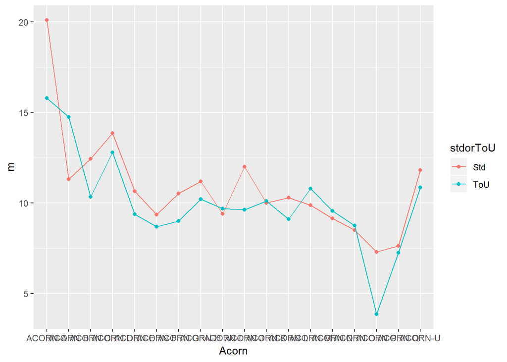

```r
#Les representem des de les dues perspectives qualitatives
ggplot(taula_daily_agrupat_acorn_tou, aes(x=Acorn, y=m, group=stdorToU, color=stdorToU))+geom_point() + geom_line()
```

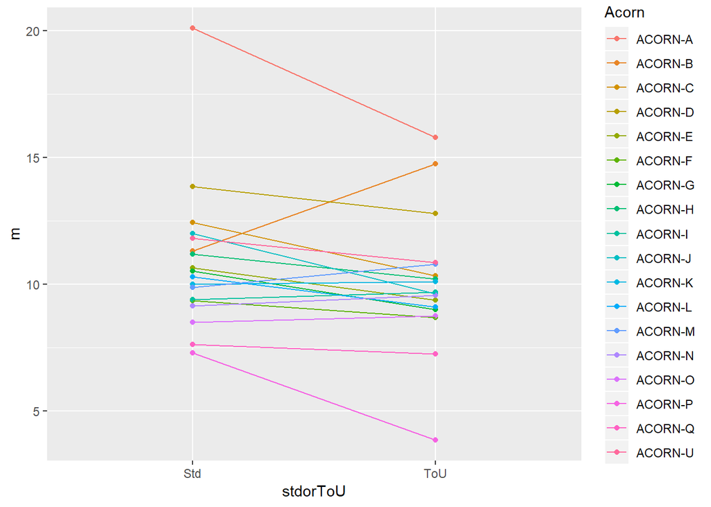

```r
ggplot(taula_daily_agrupat_acorn_tou, aes(x=stdorToU, y=m, group=Acorn, color=Acorn))+geom_point() + geom_line()
```

Es veu interacci? entre tarifa i acorn, tot i que en alguns acorns es veu molt m?s clarament.

```r
dades_friedman<-aggregate(daily$energy_sum, by=list(a=daily$Acorn, t=daily$stdorToU), FUN=mean)

friedman.test(dades_friedman$x, dades_friedman$a, dades_friedman$t)
```

```
##
##  Friedman rank sum test
##
## data:  dades_friedman$x, dades_friedman$a and dades_friedman$t
## Friedman chi-squared = 30.351, df = 17, p-value = 0.02392
```

Tamb? podem fer el test creant una variable que contingui els dos grups

```r
#Creem variable
daily$at<-paste(daily$Acorn,daily$stdorToU)
daily$at<-as.factor(daily$at)
```

```r
kruskal.test(energy_sum~at,daily)
```

```
##
##  Kruskal-Wallis rank sum test
##
## data:  energy_sum by at
## Kruskal-Wallis chi-squared = 217190, df = 35, p-value < 2.2e-16
```

```r
DunnTest(energy_sum~at,daily)
```

```
##
##  Dunn's test of multiple comparisons using rank sums : holm
##
##                         mean.rank.diff    pval
## ACORN-A ToU-ACORN-A Std    -259067.862 < 2e-16 ***
## ACORN-B Std-ACORN-A Std    -652852.824 < 2e-16 ***
## ACORN-B ToU-ACORN-A Std    -243613.084 < 2e-16 ***
## ACORN-C Std-ACORN-A Std    -481885.932 < 2e-16 ***
## ACORN-C ToU-ACORN-A Std    -728369.094 < 2e-16 ***
## ACORN-D Std-ACORN-A Std    -513099.985 < 2e-16 ***
## ACORN-D ToU-ACORN-A Std    -528465.633 < 2e-16 ***
## ACORN-E Std-ACORN-A Std    -896678.522 < 2e-16 ***
## ACORN-E ToU-ACORN-A Std   -1007456.570 < 2e-16 ***
## ACORN-F Std-ACORN-A Std    -907167.801 < 2e-16 ***
## ACORN-F ToU-ACORN-A Std    -976592.253 < 2e-16 ***
## ACORN-G Std-ACORN-A Std    -751808.340 < 2e-16 ***
## ACORN-G ToU-ACORN-A Std    -892379.609 < 2e-16 ***
## ACORN-H Std-ACORN-A Std    -580645.693 < 2e-16 ***
## ACORN-H ToU-ACORN-A Std    -687640.251 < 2e-16 ***
## ACORN-I Std-ACORN-A Std    -839733.675 < 2e-16 ***
## ACORN-I ToU-ACORN-A Std    -792199.598 < 2e-16 ***
## ACORN-J Std-ACORN-A Std    -764820.231 < 2e-16 ***
## ACORN-J ToU-ACORN-A Std    -974676.455 < 2e-16 ***
## ACORN-K Std-ACORN-A Std    -732577.079 < 2e-16 ***
## ACORN-K ToU-ACORN-A Std    -785789.309 < 2e-16 ***
## ACORN-L Std-ACORN-A Std    -690116.030 < 2e-16 ***
## ACORN-L ToU-ACORN-A Std    -843237.982 < 2e-16 ***
## ACORN-M Std-ACORN-A Std    -882280.166 < 2e-16 ***
## ACORN-M ToU-ACORN-A Std    -568108.005 < 2e-16 ***
## ACORN-N Std-ACORN-A Std    -827014.385 < 2e-16 ***
## ACORN-N ToU-ACORN-A Std    -828730.458 < 2e-16 ***
## ACORN-O Std-ACORN-A Std   -1015395.794 < 2e-16 ***
## ACORN-O ToU-ACORN-A Std   -1037855.717 < 2e-16 ***
## ACORN-P Std-ACORN-A Std   -1384115.483 < 2e-16 ***
## ACORN-P ToU-ACORN-A Std   -1964042.639 < 2e-16 ***
## ACORN-Q Std-ACORN-A Std   -1179456.225 < 2e-16 ***
## ACORN-Q ToU-ACORN-A Std   -1257135.275 < 2e-16 ***
## ACORN-U Std-ACORN-A Std    -933146.590 < 2e-16 ***
## ACORN-U ToU-ACORN-A Std    -735870.103 < 2e-16 ***
## ACORN-B Std-ACORN-A ToU    -393784.963 < 2e-16 ***
```

[output cut: 581 more lines]

```
## ACORN-Q ToU-ACORN-P Std     126980.207 < 2e-16 ***
## ACORN-U Std-ACORN-P Std     450968.892 < 2e-16 ***
## ACORN-U ToU-ACORN-P Std     648245.379 < 2e-16 ***
## ACORN-Q Std-ACORN-P ToU     784586.413 < 2e-16 ***
## ACORN-Q ToU-ACORN-P ToU     706907.363 < 2e-16 ***
## ACORN-U Std-ACORN-P ToU    1030896.049 < 2e-16 ***
## ACORN-U ToU-ACORN-P ToU    1228172.535 < 2e-16 ***
## ACORN-Q ToU-ACORN-Q Std     -77679.050 < 2e-16 ***
## ACORN-U Std-ACORN-Q Std     246309.635 < 2e-16 ***
## ACORN-U ToU-ACORN-Q Std     443586.122 < 2e-16 ***
## ACORN-U Std-ACORN-Q ToU     323988.685 < 2e-16 ***
## ACORN-U ToU-ACORN-Q ToU     521265.172 < 2e-16 ***
## ACORN-U ToU-ACORN-U Std     197276.487 < 2e-16 ***
## ---
## Signif. codes:  0 '***' 0.001 '**' 0.01 '*' 0.05 '.' 0.1 ' ' 1
```

```r
anova_tarifa_acorn<-aov(energy_sum ~ Acorn+stdorToU+Acorn*stdorToU, daily)
summary(anova_tarifa_acorn)
```

```
##                     Df    Sum Sq Mean Sq F value Pr(>F)
## Acorn               17  15488309  911077 11579.2 <2e-16 ***
## stdorToU             1    661640  661640  8409.0 <2e-16 ***
## Acorn:stdorToU      17    486751   28632   363.9 <2e-16 ***
## Residuals      3516966 276722407      79
## ---
## Signif. codes:  0 '***' 0.001 '**' 0.01 '*' 0.05 '.' 0.1 ' ' 1
```

L’an?lisi anova ens confirma la interacci? entre tarifa i acorn i confirma la influ?ncia per separat de cada variable en el valor de l’energia.

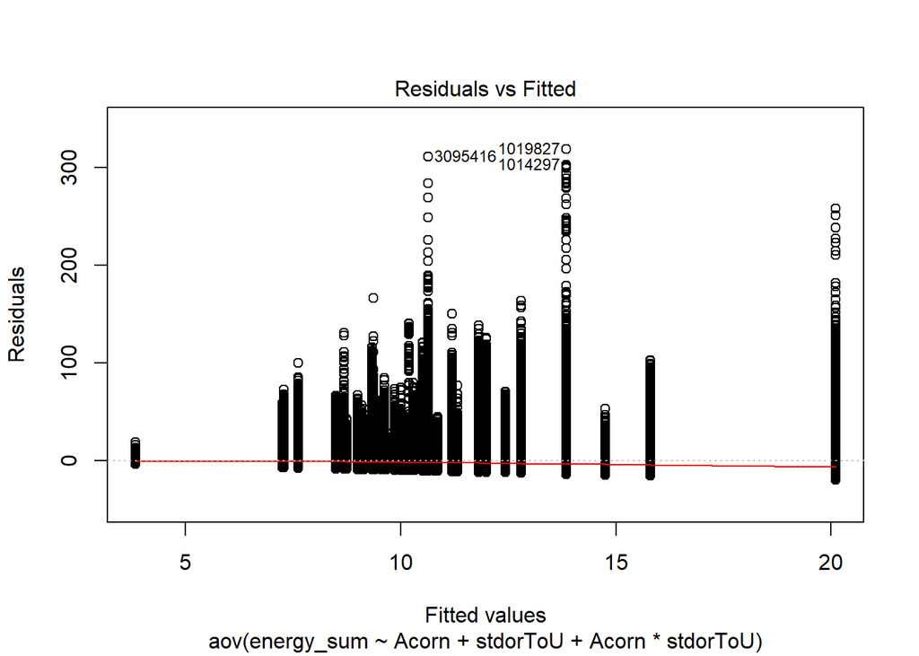

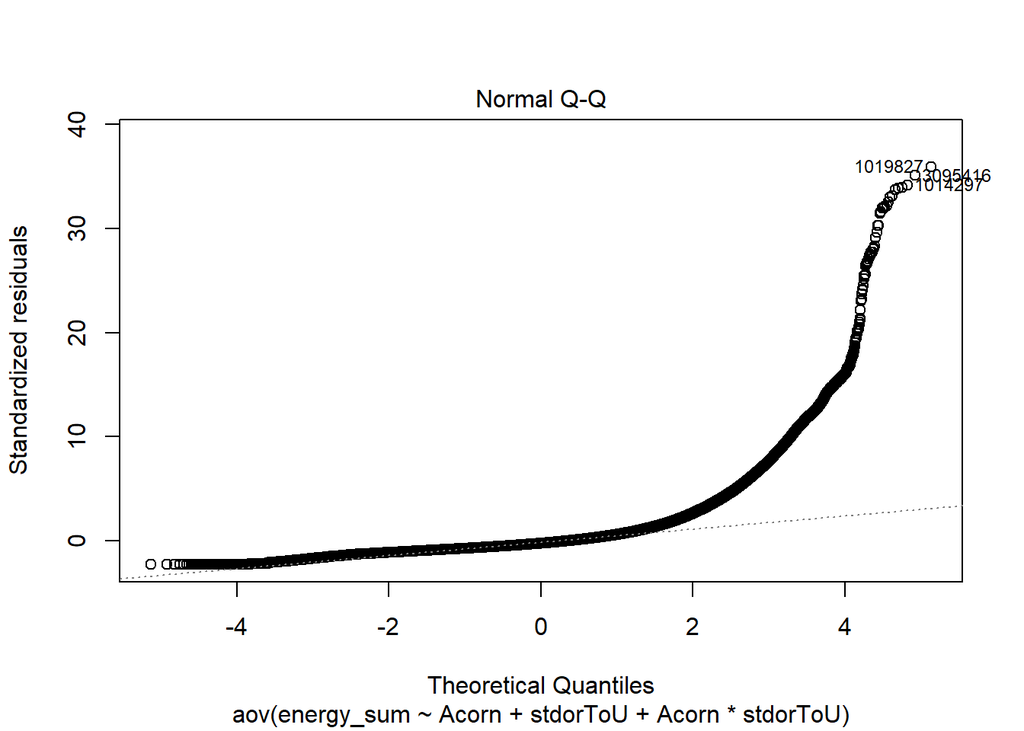

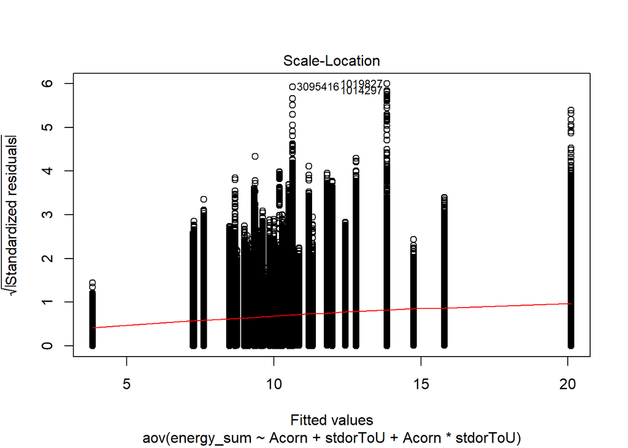

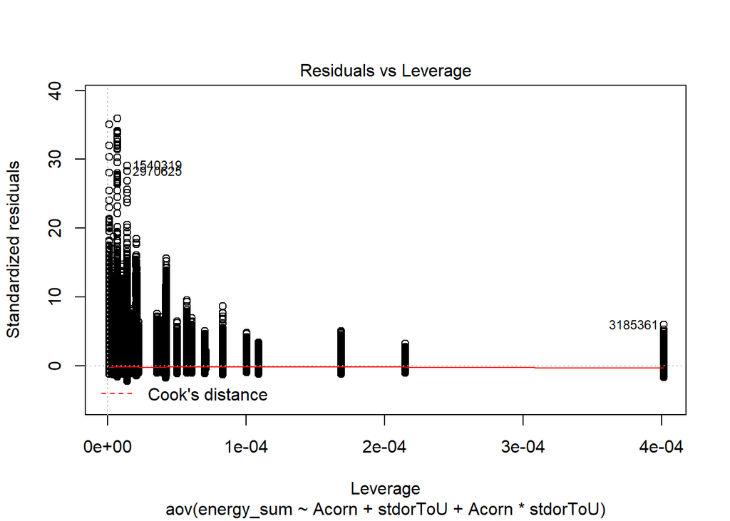

```r
plot(anova_tarifa_acorn)
```

Veiem que no hi ha normalitat dels residuus ni homoscedasticitat, de manera que l’adequaci? del model no ?s correcte.

Com que no es compleixen condicions d’aplicaci? anova: kruskal-wallis

###Acorn segons estacio

```r
#Creem variable
daily$ae<-paste(daily$Acorn,daily$season)
daily$ae<-as.factor(daily$ae)
```

```r
library(ggplot2)
#Agrupem daily per acorn i per estacio
daily %>% group_by(Acorn, season) -> daily_agrupat_acorn_season
#Mostrem les mitjanes en una taula
taula_daily_agrupat_acorn_season<-summarise(daily_agrupat_acorn_season, m=mean(energy_sum), sd=sd(energy_sum), n=length(energy_sum))
taula_daily_agrupat_acorn_season
```

```
## # A tibble: 72 x 5
## # Groups:   Acorn [18]
##    Acorn   season     m    sd     n
##    <fct>   <fct>  <dbl> <dbl> <int>
##  1 ACORN-A autumn 20.3  17.8  26509
##  2 ACORN-A spring 17.6  16.2  19402
##  3 ACORN-A summer 15.5  13.7  23349
##  4 ACORN-A winter 22.0  19.1  24786
##  5 ACORN-B autumn 13.2   9.07  4180
##  6 ACORN-B spring 10.6   7.37  2938
##  7 ACORN-B summer  9.51  5.89  3441
##  8 ACORN-B winter 13.7  10.0   3934
##  9 ACORN-C autumn 12.6   8.22 25471
## 10 ACORN-C spring 10.9   7.20 17866
## # ... with 62 more rows
```

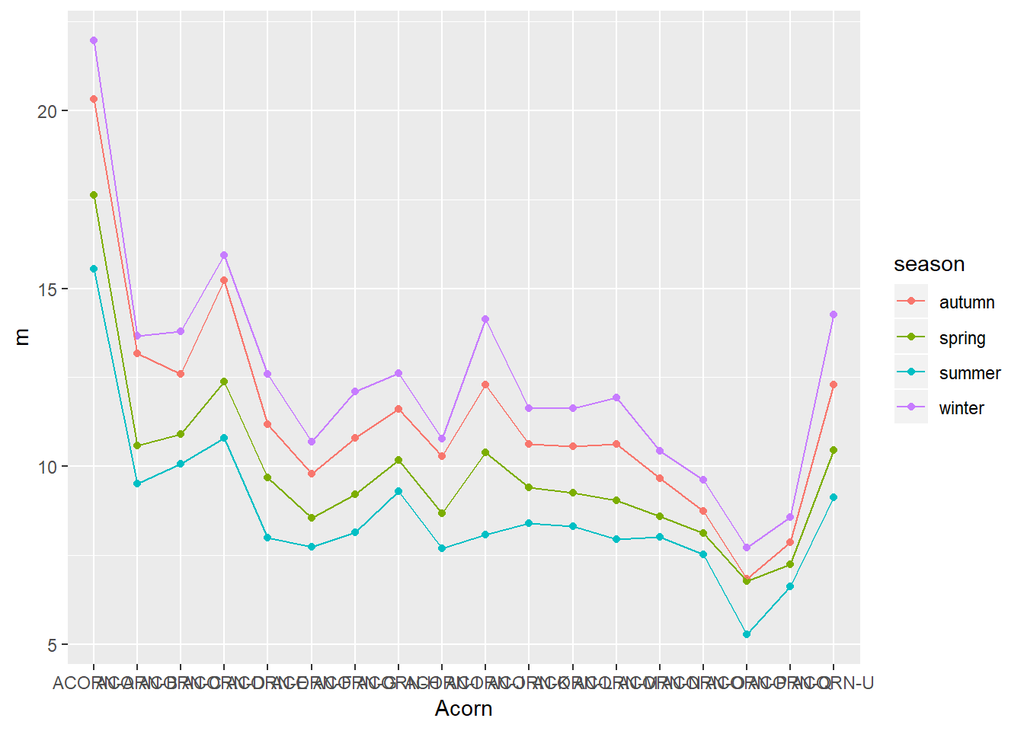

```r
#Les representem des de les dues perspectives qualitatives
ggplot(taula_daily_agrupat_acorn_season, aes(x=Acorn, y=m, group=season, color=season))+geom_point() + geom_line()
```

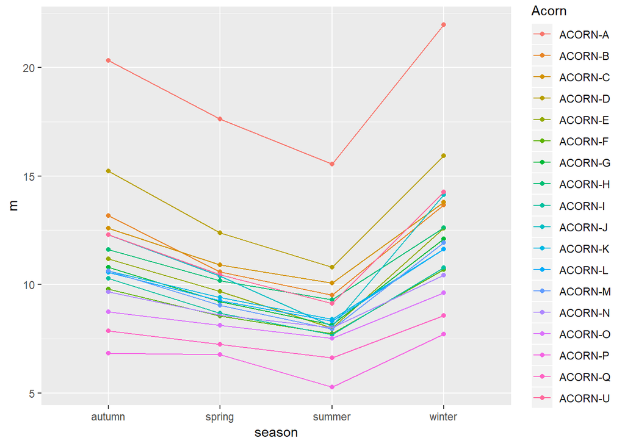

```r
ggplot(taula_daily_agrupat_acorn_season, aes(x=season, y=m, group=Acorn, color=Acorn))+geom_point() + geom_line()
```

```r
kruskal.test(energy_sum~ae,daily)
```

```
##
##  Kruskal-Wallis rank sum test
##
## data:  energy_sum by ae
## Kruskal-Wallis chi-squared = 285230, df = 71, p-value < 2.2e-16
```

```r
dun<-DunnTest(energy_sum~ae,daily)
```

##Consum cap de setmana diferent que entre setmana? (4.2.4)

finde>laboral

```r
#Calculem grups:

grup_finde<-daily$energy_sum[daily$weekday==6 | daily$weekday==7]
grup_laboral<-daily$energy_sum[daily$weekday==1 | daily$weekday==2 | daily$weekday==3 | daily$weekday==4 | daily$weekday==5 ]
```

```r
#Calculem test igualtat variancies

var.test(grup_finde,grup_laboral)
```

```
##
##  F test to compare two variances
##
## data:  grup_finde and grup_laboral
## F = 1.0503, num df = 1005400, denom df = 2511600, p-value <
## 2.2e-16
## alternative hypothesis: true ratio of variances is not equal to 1
## 95 percent confidence interval:
##  1.047380 1.053187
## sample estimates:
## ratio of variances
##           1.050278
```

```r
t.test(grup_finde, grup_laboral, conf.level=0.95, paired=FALSE, var.equal=FALSE, alternative="greater")
```

```
##
##  Welch Two Sample t-test
##
## data:  grup_finde and grup_laboral
## t = 44.865, df = 1812500, p-value < 2.2e-16
## alternative hypothesis: true difference in means is greater than 0
## 95 percent confidence interval:
##  0.4706188       Inf
## sample estimates:
## mean of x mean of y
## 10.475991  9.987462
```

p<0.05, rebutjem Ho, acceptem que mitjana consum finde és més gran que mitjana consum laboral.

###Consum finde es mes gran que isholiday?

mitjana consu finde=mitjana consum isholiday

```r
grup_holiday<-daily$energy_sum[daily$isHoliday==TRUE]
```

```r
#Calculem test igualtat variancies

var.test(grup_finde,grup_holiday)
```

```
##
##  F test to compare two variances
##
## data:  grup_finde and grup_holiday
## F = 0.92161, num df = 1005400, denom df = 80629, p-value < 2.2e-16
## alternative hypothesis: true ratio of variances is not equal to 1
## 95 percent confidence interval:
##  0.9126373 0.9306299
## sample estimates:
## ratio of variances
##           0.921612
```

```r
t.test(grup_finde, grup_holiday, conf.level=0.95, paired=FALSE, var.equal=FALSE, alternative="greater")
```

```
##
##  Welch Two Sample t-test
##
## data:  grup_finde and grup_holiday
## t = 1.7942, df = 92947, p-value = 0.03639
## alternative hypothesis: true difference in means is greater than 0
## 95 percent confidence interval:
##  0.005274247         Inf
## sample estimates:
## mean of x mean of y
##  10.47599  10.41262
```

Rebutjem H0

##Consum isholiday mes gran que consum laboral

```r
#Calculem test igualtat variancies

var.test(grup_holiday,grup_laboral)
```

```
##
##  F test to compare two variances
##
## data:  grup_holiday and grup_laboral
## F = 1.1396, num df = 80629, denom df = 2511600, p-value < 2.2e-16
## alternative hypothesis: true ratio of variances is not equal to 1
## 95 percent confidence interval:
##  1.128566 1.150816
## sample estimates:
## ratio of variances
##           1.139609
```

```r
t.test(grup_holiday, grup_laboral, conf.level=0.95, paired=FALSE, var.equal=FALSE, alternative="greater")
```

```
##
##  Welch Two Sample t-test
##
## data:  grup_holiday and grup_laboral
## t = 12.303, df = 85234, p-value < 2.2e-16
## alternative hypothesis: true difference in means is greater than 0
## 95 percent confidence interval:
##  0.3683175       Inf
## sample estimates:
## mean of x mean of y
## 10.412623  9.987462
```

##Consum dilluns diferent que divendres?

```r
daily$weekday<- as.factor(daily$weekday)
```

```r
summary(daily$weekday)
```

```
##      1      2      3      4      5      6      7
## 500557 501496 502303 503122 504106 499264 506154
```

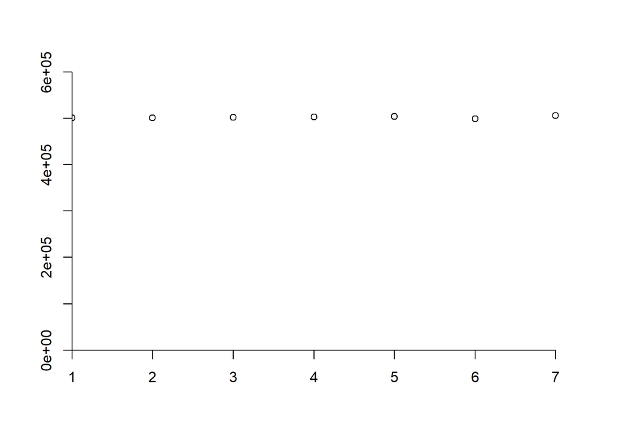

```r
plot.new()
plot.window(xlim=c(1,7.3),ylim=c(0,600000), yaxs="i", xaxs="i")
axis(1)
axis(2)
points(summary(daily$weekday))
```

Grups són força equilibrats.

```r
#Homoscedasticitat
library(car)
leveneTest(energy_sum ~ weekday,daily,center = "median")
```

```
## Levene's Test for Homogeneity of Variance (center = "median")
##            Df F value    Pr(>F)
## group       6  292.28 < 2.2e-16 ***
##       3516995
## ---
## Signif. codes:  0 '***' 0.001 '**' 0.01 '*' 0.05 '.' 0.1 ' ' 1
```

com que p<0.05, hi ha falta de homoscedasticitat.

També comprovem amb ANOVA ja que els grups són força equilibrats.

```r
#ANOVA

anova_weekday<- aov (energy_sum ~ weekday, daily)
summary(anova_weekday)
```

```
##                  Df    Sum Sq Mean Sq F value Pr(>F)
## weekday           6    244526   40754     489 <2e-16 ***
## Residuals   3516995 293114581      83
## ---
## Signif. codes:  0 '***' 0.001 '**' 0.01 '*' 0.05 '.' 0.1 ' ' 1
```

Com que p<0.05, rebutjem hipòtesis nul·la que són iguals i acceptem alternativa que almenys un grup és diferent dels altres.

```r
#Quantifiquem la diferència: comparació múltiple

TukeyHSD(anova_weekday)
```

```
##   Tukey multiple comparisons of means
##     95% family-wise confidence level
##
## Fit: aov(formula = energy_sum ~ weekday, data = daily)
##
## $weekday
##            diff         lwr         upr     p adj
## 2-1 -0.13995706 -0.19373353 -0.08618059 0.0000000
## 3-1 -0.15186892 -0.20562381 -0.09811403 0.0000000
## 4-1 -0.17193486 -0.22566790 -0.11820181 0.0000000
## 5-1 -0.23987011 -0.29357699 -0.18616322 0.0000000
## 6-1  0.10631619  0.05247970  0.16015267 0.0000001
## 7-1  0.58564703  0.53199430  0.63929975 0.0000000
## 3-2 -0.01191186 -0.06564154  0.04181782 0.9949235
## 4-2 -0.03197780 -0.08568562  0.02173002 0.5784157
## 5-2 -0.09991305 -0.15359470 -0.04623140 0.0000009
## 6-2  0.24627325  0.19246193  0.30008456 0.0000000
## 7-2  0.72560409  0.67197663  0.77923155 0.0000000
## 4-3 -0.02006594 -0.07375215  0.03362027 0.9277452
## 5-3 -0.08800119 -0.14166122 -0.03434116 0.0000274
## 6-3  0.25818511  0.20439536  0.31197485 0.0000000
## 7-3  0.73751595  0.68391013  0.79112177 0.0000000
## 5-4 -0.06793525 -0.12157340 -0.01429710 0.0035599
## 6-4  0.27825104  0.22448313  0.33201896 0.0000000
## 7-4  0.75758189  0.70399797  0.81116580 0.0000000
## 6-5  0.34618629  0.29244452  0.39992806 0.0000000
## 7-5  0.82551713  0.77195945  0.87907482 0.0000000
## 7-6  0.47933084  0.42564320  0.53301848 0.0000000
```

Com que els nombre de mostres de cada grup ?s semblant per? no igual, confirmem utilitzant Kruskal Wallis

```r
kruskal.test(energy_sum ~ weekday, daily)
```

```
##
##  Kruskal-Wallis rank sum test
##
## data:  energy_sum by weekday
## Kruskal-Wallis chi-squared = 4235.8, df = 6, p-value < 2.2e-16
```

```r
DunnTest(energy_sum ~ weekday, daily)
```

```
##
##  Dunn's test of multiple comparisons using rank sums : holm
##
##     mean.rank.diff    pval
## 2-1     -20918.066 < 2e-16 ***
## 3-1     -24747.437 < 2e-16 ***
## 4-1     -26159.686 < 2e-16 ***
## 5-1     -42614.490 < 2e-16 ***
## 6-1      10084.311 2.7e-06 ***
## 7-1      71718.562 < 2e-16 ***
## 3-2      -3829.371  0.1177
## 4-2      -5241.621  0.0290 *
## 5-2     -21696.424 < 2e-16 ***
## 6-2      31002.377 < 2e-16 ***
## 7-2      92636.628 < 2e-16 ***
## 4-3      -1412.250  0.4856
## 5-3     -17867.053 < 2e-16 ***
## 6-3      34831.748 < 2e-16 ***
## 7-3      96465.999 < 2e-16 ***
## 5-4     -16454.804 2.1e-15 ***
## 6-4      36243.997 < 2e-16 ***
## 7-4      97878.249 < 2e-16 ***
## 6-5      52698.801 < 2e-16 ***
## 7-5     114333.052 < 2e-16 ***
## 7-6      61634.251 < 2e-16 ***
## ---
## Signif. codes:  0 '***' 0.001 '**' 0.01 '*' 0.05 '.' 0.1 ' ' 1
```

##Es consumeix més en isHoliday que en treball? #######CHauria de fer-ho amb l’estaci? mitjana_consum_Holiday>mitjana_consum_noHoliday

```r
#Calculem grups:

grup_holiday<-daily$energy_sum[daily$isHoliday==TRUE]
grup_no_holiday<-daily$energy_sum[daily$isHoliday==FALSE]
```

```r
#Calculem test igualtat variancies

var.test(grup_holiday,grup_no_holiday)
```

```
##
##  F test to compare two variances
##
## data:  grup_holiday and grup_no_holiday
## F = 1.1261, num df = 80629, denom df = 3436400, p-value < 2.2e-16
## alternative hypothesis: true ratio of variances is not equal to 1
## 95 percent confidence interval:
##  1.115165 1.137150
## sample estimates:
## ratio of variances
##           1.126077
```

```r
t.test(grup_holiday, grup_no_holiday, conf.level=0.95, paired=FALSE, var.equal=FALSE, alternative="greater")
```

```
##
##  Welch Two Sample t-test
##
## data:  grup_holiday and grup_no_holiday
## t = 8.4857, df = 84023, p-value < 2.2e-16
## alternative hypothesis: true difference in means is greater than 0
## 95 percent confidence interval:
##  0.2355618       Inf
## sample estimates:
## mean of x mean of y
##  10.41262  10.12042
```

```r
#Homoscedasticitat
library(car)
leveneTest(energy_sum ~ isHoliday,daily,center = "median")
```

```
## Levene's Test for Homogeneity of Variance (center = "median")
##            Df F value    Pr(>F)
## group       1  331.67 < 2.2e-16 ***
##       3517000
## ---
## Signif. codes:  0 '***' 0.001 '**' 0.01 '*' 0.05 '.' 0.1 ' ' 1
```

com que p<0.05, hi ha falta de homoscedasticitat.

##Es consumeix menys a l’abril que al desembre? (4.2.5)

```r
daily$month<- as.factor(daily$month)
```

```r
summary(daily$month)
```

```
##      1      2      3      4      5      6      7      8      9     10
## 342674 314846 206860 209773 256900 279965 307947 310945 302239 325701
##     11     12
## 321297 337855
```

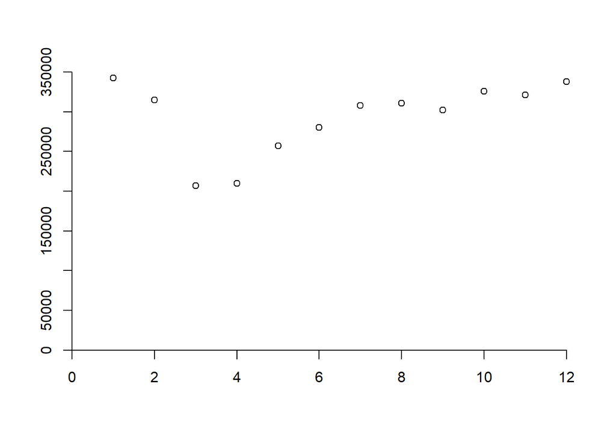

```r
plot.new()
plot.window(xlim=c(0,12.3),ylim=c(0,350000), yaxs="i", xaxs="i")
axis(1)
axis(2)
points(summary(daily$month))
```

Grups no equilibrats.

```r
#Homoscedasticitat
library(car)
leveneTest(energy_sum ~ month,daily,center = "median")
```

```
## Levene's Test for Homogeneity of Variance (center = "median")
##            Df F value    Pr(>F)
## group      11  7164.3 < 2.2e-16 ***
##       3516990
## ---
## Signif. codes:  0 '***' 0.001 '**' 0.01 '*' 0.05 '.' 0.1 ' ' 1
```

com que p<0.05, hi ha falta de homoscedasticitat.

Fem Kruskal:

```r
kruskal.test(energy_sum~month, daily)
```

```
##
##  Kruskal-Wallis rank sum test
##
## data:  energy_sum by month
## Kruskal-Wallis chi-squared = 100520, df = 11, p-value < 2.2e-16
```

com que p<0.05, acceptem H1, mitjanes segons mes son diferents.

Quantifiquem:

```r
DunnTest(energy_sum~month, daily, method="bonferroni")
```

```
##
##  Dunn's test of multiple comparisons using rank sums : bonferroni
##
##       mean.rank.diff    pval
## 2-1       -58752.595 < 2e-16 ***
## 3-1       -42789.497 < 2e-16 ***
## 4-1      -207136.697 < 2e-16 ***
## 5-1      -340031.619 < 2e-16 ***
## 6-1      -405889.685 < 2e-16 ***
## 7-1      -428878.396 < 2e-16 ***
## 8-1      -461767.933 < 2e-16 ***
## 9-1      -354383.734 < 2e-16 ***
## 10-1     -210096.407 < 2e-16 ***
## 11-1      -67192.461 < 2e-16 ***
## 12-1      -12787.159 1.4e-05 ***
## 3-2        15963.097 1.8e-06 ***
## 4-2      -148384.102 < 2e-16 ***
## 5-2      -281279.025 < 2e-16 ***
## 6-2      -347137.090 < 2e-16 ***
## 7-2      -370125.801 < 2e-16 ***
## 8-2      -403015.338 < 2e-16 ***
## 9-2      -295631.140 < 2e-16 ***
## 10-2     -151343.812 < 2e-16 ***
## 11-2       -8439.866  0.0605 .
## 12-2       45965.436 < 2e-16 ***
## 4-3      -164347.200 < 2e-16 ***
## 5-3      -297242.122 < 2e-16 ***
## 6-3      -363100.188 < 2e-16 ***
## 7-3      -386088.898 < 2e-16 ***
## 8-3      -418978.435 < 2e-16 ***
## 9-3      -311594.237 < 2e-16 ***
## 10-3     -167306.910 < 2e-16 ***
## 11-3      -24402.964 1.0e-15 ***
## 12-3       30002.338 < 2e-16 ***
## 5-4      -132894.922 < 2e-16 ***
## 6-4      -198752.988 < 2e-16 ***
## 7-4      -221741.699 < 2e-16 ***
## 8-4      -254631.236 < 2e-16 ***
## 9-4      -147247.037 < 2e-16 ***
## 10-4       -2959.710  1.0000
```

[output cut: 17 more lines]

```
## 10-7      218781.989 < 2e-16 ***
## 11-7      361685.935 < 2e-16 ***
## 12-7      416091.237 < 2e-16 ***
## 9-8       107384.198 < 2e-16 ***
## 10-8      251671.526 < 2e-16 ***
## 11-8      394575.472 < 2e-16 ***
## 12-8      448980.774 < 2e-16 ***
## 10-9      144287.327 < 2e-16 ***
## 11-9      287191.273 < 2e-16 ***
## 12-9      341596.575 < 2e-16 ***
## 11-10     142903.946 < 2e-16 ***
## 12-10     197309.248 < 2e-16 ***
## 12-11      54405.302 < 2e-16 ***
## ---
## Signif. codes:  0 '***' 0.001 '**' 0.01 '*' 0.05 '.' 0.1 ' ' 1
```

```r
DunnTest(energy_sum~month, daily)
```

```
##
##  Dunn's test of multiple comparisons using rank sums : holm
##
##       mean.rank.diff    pval
## 2-1       -58752.595 < 2e-16 ***
## 3-1       -42789.497 < 2e-16 ***
## 4-1      -207136.697 < 2e-16 ***
## 5-1      -340031.619 < 2e-16 ***
## 6-1      -405889.685 < 2e-16 ***
## 7-1      -428878.396 < 2e-16 ***
## 8-1      -461767.933 < 2e-16 ***
## 9-1      -354383.734 < 2e-16 ***
## 10-1     -210096.407 < 2e-16 ***
## 11-1      -67192.461 < 2e-16 ***
## 12-1      -12787.159 6.1e-07 ***
## 3-2        15963.097 1.4e-07 ***
## 4-2      -148384.102 < 2e-16 ***
## 5-2      -281279.025 < 2e-16 ***
## 6-2      -347137.090 < 2e-16 ***
## 7-2      -370125.801 < 2e-16 ***
## 8-2      -403015.338 < 2e-16 ***
## 9-2      -295631.140 < 2e-16 ***
## 10-2     -151343.812 < 2e-16 ***
## 11-2       -8439.866  0.0018 **
## 12-2       45965.436 < 2e-16 ***
## 4-3      -164347.200 < 2e-16 ***
## 5-3      -297242.122 < 2e-16 ***
## 6-3      -363100.188 < 2e-16 ***
## 7-3      -386088.898 < 2e-16 ***
## 8-3      -418978.435 < 2e-16 ***
## 9-3      -311594.237 < 2e-16 ***
## 10-3     -167306.910 < 2e-16 ***
## 11-3      -24402.964 < 2e-16 ***
## 12-3       30002.338 < 2e-16 ***
## 5-4      -132894.922 < 2e-16 ***
## 6-4      -198752.988 < 2e-16 ***
## 7-4      -221741.699 < 2e-16 ***
## 8-4      -254631.236 < 2e-16 ***
## 9-4      -147247.037 < 2e-16 ***
## 10-4       -2959.710  0.2977
```

[output cut: 17 more lines]

```
## 10-7      218781.989 < 2e-16 ***
## 11-7      361685.935 < 2e-16 ***
## 12-7      416091.237 < 2e-16 ***
## 9-8       107384.198 < 2e-16 ***
## 10-8      251671.526 < 2e-16 ***
## 11-8      394575.472 < 2e-16 ***
## 12-8      448980.774 < 2e-16 ***
## 10-9      144287.327 < 2e-16 ***
## 11-9      287191.273 < 2e-16 ***
## 12-9      341596.575 < 2e-16 ***
## 11-10     142903.946 < 2e-16 ***
## 12-10     197309.248 < 2e-16 ***
## 12-11      54405.302 < 2e-16 ***
## ---
## Signif. codes:  0 '***' 0.001 '**' 0.01 '*' 0.05 '.' 0.1 ' ' 1
```

```r
library(DescTools)
DunnTest(energy_sum~month, daily, method="BH")
```

```
##
##  Dunn's test of multiple comparisons using rank sums : BH
##
##       mean.rank.diff    pval
## 2-1       -58752.595 < 2e-16 ***
## 3-1       -42789.497 < 2e-16 ***
## 4-1      -207136.697 < 2e-16 ***
## 5-1      -340031.619 < 2e-16 ***
## 6-1      -405889.685 < 2e-16 ***
## 7-1      -428878.396 < 2e-16 ***
## 8-1      -461767.933 < 2e-16 ***
## 9-1      -354383.734 < 2e-16 ***
## 10-1     -210096.407 < 2e-16 ***
## 11-1      -67192.461 < 2e-16 ***
## 12-1      -12787.159 2.1e-07 ***
## 3-2        15963.097 2.9e-08 ***
## 4-2      -148384.102 < 2e-16 ***
## 5-2      -281279.025 < 2e-16 ***
## 6-2      -347137.090 < 2e-16 ***
## 7-2      -370125.801 < 2e-16 ***
## 8-2      -403015.338 < 2e-16 ***
## 9-2      -295631.140 < 2e-16 ***
## 10-2     -151343.812 < 2e-16 ***
## 11-2       -8439.866 0.00093 ***
## 12-2       45965.436 < 2e-16 ***
## 4-3      -164347.200 < 2e-16 ***
## 5-3      -297242.122 < 2e-16 ***
## 6-3      -363100.188 < 2e-16 ***
## 7-3      -386088.898 < 2e-16 ***
## 8-3      -418978.435 < 2e-16 ***
## 9-3      -311594.237 < 2e-16 ***
## 10-3     -167306.910 < 2e-16 ***
## 11-3      -24402.964 < 2e-16 ***
## 12-3       30002.338 < 2e-16 ***
## 5-4      -132894.922 < 2e-16 ***
## 6-4      -198752.988 < 2e-16 ***
## 7-4      -221741.699 < 2e-16 ***
## 8-4      -254631.236 < 2e-16 ***
## 9-4      -147247.037 < 2e-16 ***
## 10-4       -2959.710 0.29773
```

[output cut: 17 more lines]

```
## 10-7      218781.989 < 2e-16 ***
## 11-7      361685.935 < 2e-16 ***
## 12-7      416091.237 < 2e-16 ***
## 9-8       107384.198 < 2e-16 ***
## 10-8      251671.526 < 2e-16 ***
## 11-8      394575.472 < 2e-16 ***
## 12-8      448980.774 < 2e-16 ***
## 10-9      144287.327 < 2e-16 ***
## 11-9      287191.273 < 2e-16 ***
## 12-9      341596.575 < 2e-16 ***
## 11-10     142903.946 < 2e-16 ***
## 12-10     197309.248 < 2e-16 ***
## 12-11      54405.302 < 2e-16 ***
## ---
## Signif. codes:  0 '***' 0.001 '**' 0.01 '*' 0.05 '.' 0.1 ' ' 1
```

##Es consumeix més a l’estació hivern que a l’estació estiu? (4.2.6)

```r
summary(daily$season)
```

```
## autumn spring summer winter
## 956149 740191 925246 895416
```

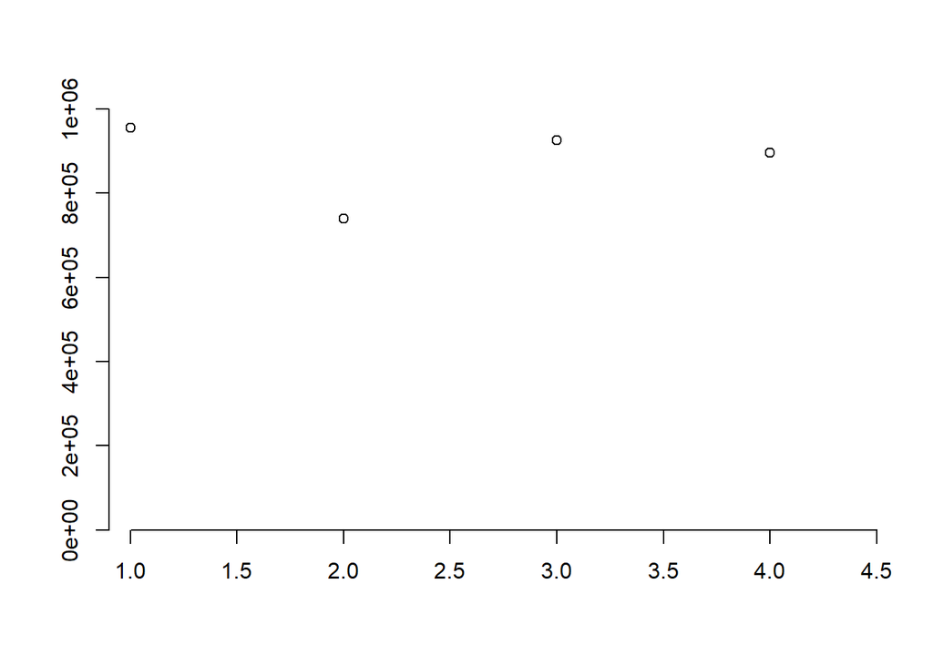

```r
plot.new()
plot.window(xlim=c(0.9,4.5),ylim=c(0,1000000), yaxs="i", xaxs="i")
axis(1)
axis(2)
points(summary(daily$season))
```

Grups no equilibrats.

```r
#Homoscedasticitat
library(car)
leveneTest(energy_sum ~ season,daily,center = "median")
```

```
## Levene's Test for Homogeneity of Variance (center = "median")
##            Df F value    Pr(>F)
## group       3   20309 < 2.2e-16 ***
##       3516998
## ---
## Signif. codes:  0 '***' 0.001 '**' 0.01 '*' 0.05 '.' 0.1 ' ' 1
```

com que p<0.05, hi ha falta de homoscedasticitat.

```r
kruskal.test(energy_sum ~ season, daily)
```

```
##
##  Kruskal-Wallis rank sum test
##
## data:  energy_sum by season
## Kruskal-Wallis chi-squared = 81527, df = 3, p-value < 2.2e-16
```

```r
DunnTest(energy_sum ~ season, daily)
```

```
##
##  Dunn's test of multiple comparisons using rank sums : holm
##
##               mean.rank.diff   pval
## spring-autumn     -174201.48 <2e-16 ***
## summer-autumn     -308636.08 <2e-16 ***
## winter-autumn       83545.17 <2e-16 ***
## summer-spring     -134434.61 <2e-16 ***
## winter-spring      257746.64 <2e-16 ***
## winter-summer      392181.25 <2e-16 ***
## ---
## Signif. codes:  0 '***' 0.001 '**' 0.01 '*' 0.05 '.' 0.1 ' ' 1
```

```r
DunnTest(energy_sum ~ season, daily, method="bonferroni")
```

```
##
##  Dunn's test of multiple comparisons using rank sums : bonferroni
##
##               mean.rank.diff   pval
## spring-autumn     -174201.48 <2e-16 ***
## summer-autumn     -308636.08 <2e-16 ***
## winter-autumn       83545.17 <2e-16 ***
## summer-spring     -134434.61 <2e-16 ***
## winter-spring      257746.64 <2e-16 ***
## winter-summer      392181.25 <2e-16 ***
## ---
## Signif. codes:  0 '***' 0.001 '**' 0.01 '*' 0.05 '.' 0.1 ' ' 1
```

```r
DunnTest(energy_sum ~ season, daily, method="BH")
```

```
##
##  Dunn's test of multiple comparisons using rank sums : BH
##
##               mean.rank.diff   pval
## spring-autumn     -174201.48 <2e-16 ***
## summer-autumn     -308636.08 <2e-16 ***
## winter-autumn       83545.17 <2e-16 ***
## summer-spring     -134434.61 <2e-16 ***
## winter-spring      257746.64 <2e-16 ***
## winter-summer      392181.25 <2e-16 ***
## ---
## Signif. codes:  0 '***' 0.001 '**' 0.01 '*' 0.05 '.' 0.1 ' ' 1
```

```r
#ANOVA

anova_season<- aov (energy_sum ~ season, daily)
summary(anova_season)
```

```
##                  Df    Sum Sq Mean Sq F value Pr(>F)
## season            3   7098290 2366097   29070 <2e-16 ***
## Residuals   3516998 286260817      81
## ---
## Signif. codes:  0 '***' 0.001 '**' 0.01 '*' 0.05 '.' 0.1 ' ' 1
```

Com que p<0.05, rebutjem hipòtesis nul·la que són iguals i acceptem alternativa que almenys un grup és diferent dels altres.

```r
#Quantifiquem la diferència: comparació múltiple

TukeyHSD(anova_season)
```

```
##   Tukey multiple comparisons of means
##     95% family-wise confidence level
##
## Fit: aov(formula = energy_sum ~ season, data = daily)
##
## $season
##                    diff       lwr       upr p adj
## spring-autumn -1.399488 -1.435371 -1.363605     0
## summer-autumn -2.606050 -2.639850 -2.572250     0
## winter-autumn  1.101558  1.067473  1.135642     0
## summer-spring -1.206562 -1.242706 -1.170419     0
## winter-spring  2.501045  2.464636  2.537455     0
## winter-summer  3.707608  3.673249  3.741967     0
```

Veiem que totes les estacions es comporten diferent.

#???Es consumeix diferent a l’hivern que a les altres estacions?

```r
summary(daily$season)
```

```
## autumn spring summer winter
## 956149 740191 925246 895416
```

```r
hivern<-daily$energy_sum[daily$season=="winter"]
altres<-daily$energy_sum[daily$season=="summer" | daily$season=="autumn" | daily$season=="spring"]
```

```r
#Calculem test igualtat variancies

var.test(hivern,altres)
```

```
##
##  F test to compare two variances
##
## data:  hivern and altres
## F = 1.7817, num df = 895420, denom df = 2621600, p-value < 2.2e-16
## alternative hypothesis: true ratio of variances is not equal to 1
## 95 percent confidence interval:
##  1.776497 1.786935
## sample estimates:
## ratio of variances
##           1.781704
```

```r
t.test(hivern, altres, conf.level=0.95, paired=FALSE, var.equal=FALSE, alternative="greater")
```

```
##
##  Welch Two Sample t-test
##
## data:  hivern and altres
## t = 189.41, df = 1255900, p-value < 2.2e-16
## alternative hypothesis: true difference in means is greater than 0
## 95 percent confidence interval:
##  2.395473      Inf
## sample estimates:
## mean of x mean of y
## 11.928356  9.511898
```

#Consum hivern i estiu diferent?

```r
estiu<-daily$energy_sum[daily$season=="summer" ]
```

```r
var.test(hivern,estiu)
```

```
##
##  F test to compare two variances
##
## data:  hivern and estiu
## F = 3.0073, num df = 895420, denom df = 925240, p-value < 2.2e-16
## alternative hypothesis: true ratio of variances is not equal to 1
## 95 percent confidence interval:
##  2.998532 3.016150
## sample estimates:
## ratio of variances
##           3.007322
```

```r
t.test(hivern, estiu, conf.level=0.95, paired=FALSE, var.equal=FALSE, alternative="greater")
```

```
##
##  Welch Two Sample t-test
##
## data:  hivern and estiu
## t = 275.94, df = 1421900, p-value < 2.2e-16
## alternative hypothesis: true difference in means is greater than 0
## 95 percent confidence interval:
##  3.685507      Inf
## sample estimates:
## mean of x mean of y
## 11.928356  8.220749
```

#Consum tardor i primavera diferent?

```r
tardor<-daily$energy_sum[daily$season=="autumn" ]

primavera<-daily$energy_sum[daily$season=="spring" ]
```

```r
var.test(tardor,primavera)
```

```
##
##  F test to compare two variances
##
## data:  tardor and primavera
## F = 1.3979, num df = 956150, denom df = 740190, p-value < 2.2e-16
## alternative hypothesis: true ratio of variances is not equal to 1
## 95 percent confidence interval:
##  1.393372 1.402379
## sample estimates:
## ratio of variances
##           1.397872
```

```r
t.test(tardor, primavera, conf.level=0.95, paired=FALSE, var.equal=FALSE, alternative="greater")
```

```
##
##  Welch Two Sample t-test
##
## data:  tardor and primavera
## t = 101.95, df = 1683100, p-value < 2.2e-16
## alternative hypothesis: true difference in means is greater than 0
## 95 percent confidence interval:
##  1.376908      Inf
## sample estimates:
## mean of x mean of y
## 10.826799  9.427311
```

##Hivern tardor

```r
t.test(hivern, tardor, conf.level=0.95, paired=FALSE, var.equal=FALSE, alternative="greater")
```

```
##
##  Welch Two Sample t-test
##
## data:  hivern and tardor
## t = 71.931, df = 1781900, p-value < 2.2e-16
## alternative hypothesis: true difference in means is greater than 0
## 95 percent confidence interval:
##  1.076368      Inf
## sample estimates:
## mean of x mean of y
##  11.92836  10.82680
```

```r
t.test(primavera, estiu, conf.level=0.95, paired=FALSE, var.equal=FALSE, alternative="greater")
```

```
##
##  Welch Two Sample t-test
##
## data:  primavera and estiu
## t = 104.05, df = 1374400, p-value < 2.2e-16
## alternative hypothesis: true difference in means is greater than 0
## 95 percent confidence interval:
##  1.187489      Inf
## sample estimates:
## mean of x mean of y
##  9.427311  8.220749
```

##Es consumeix més segons icon?

```r
summary(daily$icon)
```

```
##           clear-day              cloudy                 fog
##               21047               41537              270100
##   partly-cloudy-day partly-cloudy-night                wind
##             2568335              102976              513007
```

Grupsno són equilibrats.

```r
#Homoscedasticitat
library(car)
leveneTest(energy_sum ~ icon,daily,center = "median")
```

```
## Levene's Test for Homogeneity of Variance (center = "median")
##            Df F value    Pr(>F)
## group       5  1191.1 < 2.2e-16 ***
##       3516996
## ---
## Signif. codes:  0 '***' 0.001 '**' 0.01 '*' 0.05 '.' 0.1 ' ' 1
```

com que p<0.05, hi ha falta de homoscedasticitat.

Fem ANOVA heterodàstica: Welch test

```r
oneway.test(energy_sum ~ icon, daily)
```

```
##
##  One-way analysis of means (not assuming equal variances)
##
## data:  energy_sum and icon
## F = 1713.2, num df = 5, denom df = 137970, p-value < 2.2e-16
```

Fem anova per poder fer la coparació múltiple

```r
#ANOVA
anova_icon<- aov (energy_sum ~ icon, daily)
summary(anova_icon)
```

```
##                  Df    Sum Sq Mean Sq F value Pr(>F)
## icon              5    868456  173691    2089 <2e-16 ***
## Residuals   3516996 292490651      83
## ---
## Signif. codes:  0 '***' 0.001 '**' 0.01 '*' 0.05 '.' 0.1 ' ' 1
```

```r
#Quantifiquem la diferència: comparació múltiple

TukeyHSD(anova_icon)
```

```
##   Tukey multiple comparisons of means
##     95% family-wise confidence level
##
## Fit: aov(formula = energy_sum ~ icon, data = daily)
##
## $icon
##                                               diff        lwr        upr
## cloudy-clear-day                       1.054176954  0.8342953  1.2740586
## fog-clear-day                          1.530797881  1.3448168  1.7167790
## partly-cloudy-day-clear-day            0.318181216  0.1383160  0.4980464
## partly-cloudy-night-clear-day          2.339638821  2.1430504  2.5362273
## wind-clear-day                         1.049353499  0.8665831  1.2321239
## fog-cloudy                             0.476620927  0.3396543  0.6135875
## partly-cloudy-day-cloudy              -0.735995738 -0.8645351 -0.6074563
## partly-cloudy-night-cloudy             1.285461867  1.1344059  1.4365178
## wind-cloudy                           -0.004823455 -0.1373976  0.1277507
## partly-cloudy-day-fog                 -1.212616665 -1.2651847 -1.1600487
## partly-cloudy-night-fog                0.808840939  0.7136625  0.9040193
## wind-fog                              -0.481444382 -0.5432256 -0.4196631
## partly-cloudy-night-partly-cloudy-day  2.021457605  1.9388655  2.1040497
## wind-partly-cloudy-day                 0.731172283  0.6914300  0.7709145
## wind-partly-cloudy-night              -1.290285322 -1.3790264 -1.2015442
##                                           p adj
## cloudy-clear-day                      0.0000000
## fog-clear-day                         0.0000000
## partly-cloudy-day-clear-day           0.0000069
## partly-cloudy-night-clear-day         0.0000000
## wind-clear-day                        0.0000000
## fog-cloudy                            0.0000000
## partly-cloudy-day-cloudy              0.0000000
## partly-cloudy-night-cloudy            0.0000000
## wind-cloudy                           0.9999983
## partly-cloudy-day-fog                 0.0000000
## partly-cloudy-night-fog               0.0000000
## wind-fog                              0.0000000
## partly-cloudy-night-partly-cloudy-day 0.0000000
## wind-partly-cloudy-day                0.0000000
## wind-partly-cloudy-night              0.0000000
```

##Canvia el consum amb la temperatura? Afegim variables qualitatives de la temperatura maxima i temperatura minima

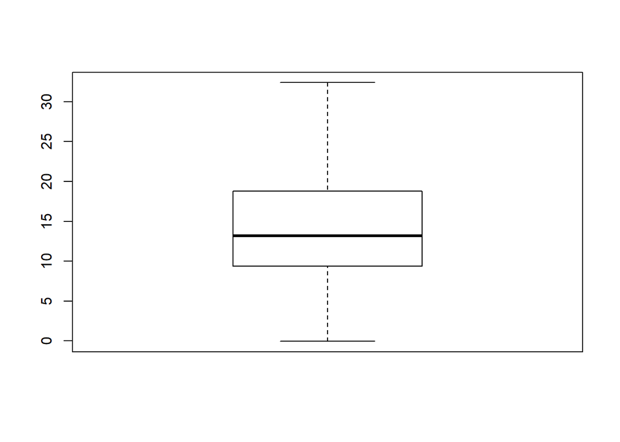

```r
boxplot(daily$temperatureMax)
```

```r
summary(daily$temperatureMax)
```

```
##    Min. 1st Qu.  Median    Mean 3rd Qu.    Max.
##   -0.06    9.37   13.18   14.12   18.81   32.40
```

```r
summary(daily$temperatureMin)
```

```
##    Min. 1st Qu.  Median    Mean 3rd Qu.    Max.
##  -5.640   3.640   7.580   7.847  12.070  20.540
```

```r
daily$tempMaxFactor [daily$temperatureMax< 33.00 ]   <- "Molt Alta"
daily$tempMaxFactor [daily$temperatureMax< 30.00 ]   <- "Alta"
daily$tempMaxFactor [daily$temperatureMax< 21.00 ]   <- "Normal"
daily$tempMaxFactor [daily$temperatureMax< 12.00 ]   <- "Baixa"
daily$tempMaxFactor [daily$temperatureMax< 3.00 ]   <- "Molt Baixa"

daily$tempMaxFactor<-as.factor((daily$tempMaxFactor))
```

```r
summary(daily$tempMaxFactor)
```

```
##       Alta      Baixa  Molt Alta Molt Baixa     Normal
##     555374    1377264      15910     149008    1419446
```

```r
#Homoscedasticitat
library(car)
leveneTest(energy_sum ~ tempMaxFactor,daily,center = "median")
```

```
## Levene's Test for Homogeneity of Variance (center = "median")
##            Df F value    Pr(>F)
## group       4   17368 < 2.2e-16 ***
##       3516997
## ---
## Signif. codes:  0 '***' 0.001 '**' 0.01 '*' 0.05 '.' 0.1 ' ' 1
```

com que p<0.05, hi ha falta de homoscedasticitat.

Kruskal

```r
kruskal.test(energy_sum ~ tempMaxFactor, daily)
```

```
##
##  Kruskal-Wallis rank sum test
##
## data:  energy_sum by tempMaxFactor
## Kruskal-Wallis chi-squared = 81767, df = 4, p-value < 2.2e-16
```

```r
#Dunn's Kruskal-Wallis Multiple Comparisons.

DunnTest(energy_sum~tempMaxFactor,daily,method="holm")
```

```
##
##  Dunn's test of multiple comparisons using rank sums : holm
##
##                      mean.rank.diff   pval
## Baixa-Alta                 382421.0 <2e-16 ***
## Molt Alta-Alta              11460.8 0.1604
## Molt Baixa-Alta            516807.0 <2e-16 ***
## Normal-Alta                146516.5 <2e-16 ***
## Molt Alta-Baixa           -370960.2 <2e-16 ***
## Molt Baixa-Baixa           134386.0 <2e-16 ***
## Normal-Baixa              -235904.5 <2e-16 ***
## Molt Baixa-Molt Alta       505346.2 <2e-16 ***
## Normal-Molt Alta           135055.7 <2e-16 ***
## Normal-Molt Baixa         -370290.5 <2e-16 ***
## ---
## Signif. codes:  0 '***' 0.001 '**' 0.01 '*' 0.05 '.' 0.1 ' ' 1
```

```r
DunnTest(energy_sum~tempMaxFactor,daily,method="bonferroni")
```

```
##
##  Dunn's test of multiple comparisons using rank sums : bonferroni
##
##                      mean.rank.diff   pval
## Baixa-Alta                 382421.0 <2e-16 ***
## Molt Alta-Alta              11460.8 1.0000
## Molt Baixa-Alta            516807.0 <2e-16 ***
## Normal-Alta                146516.5 <2e-16 ***
## Molt Alta-Baixa           -370960.2 <2e-16 ***
## Molt Baixa-Baixa           134386.0 <2e-16 ***
## Normal-Baixa              -235904.5 <2e-16 ***
## Molt Baixa-Molt Alta       505346.2 <2e-16 ***
## Normal-Molt Alta           135055.7 <2e-16 ***
## Normal-Molt Baixa         -370290.5 <2e-16 ***
## ---
## Signif. codes:  0 '***' 0.001 '**' 0.01 '*' 0.05 '.' 0.1 ' ' 1
```

```r
#No utilitzem tukey ja que els grups no son equilibrats
```

#Clústering kmeans (eliminat)

```r
daily_cluster<-select(daily, energy_sum,temperatureMax,temperatureMin, dewPoint,uvIndex, sunsetTimeHour,  humidity, visibility, cloudCover,  month, weekday)

#daily_cluster<-select(daily, LCLid, date, energy_sum,temperatureMax,temperatureMin, isHoliday, season, stdorToU, Acorn, Acorn_grouped,dewPoint,uvIndex, sunsetTimeHour,  humidity, visibility, cloudCover, icon, month, weekday)
```

```r
# Creem variable SSE buida
#SSE <- rep(0,10)

#Rang de k que utilitzem
#K=range(1:10)

#Per cada valor de k entre 1 i 10
#for (i in K){

#    kmeanModel <- kmeans(daily, i) #Aplicar kMeans

    #Afegim suma distancies al quadrat del punt al centre més proper a la llista
#    SSE[i]<-kmeanModel$tot.withinss
#}

# Gràfic del colze

#plot(2:10,SSE[2:10], xlab="Nombre de clústers (k)", ylab="SSE (tot.withins)")
```

```r
SSE <- rep(0,10)
fit_kmeans_2 <- kmeans(daily_cluster, 2)
SSE[2]<-fit_kmeans_2$tot.withinss
fit_kmeans_3 <- kmeans(daily_cluster, 3)
SSE[3]<-fit_kmeans_3$tot.withinss

fit_kmeans_4 <- kmeans(daily_cluster, 4)
SSE[4]<-fit_kmeans_4$tot.withinss

fit_kmeans_5 <- kmeans(daily_cluster, 5)
SSE[5]<-fit_kmeans_5$tot.withinss

fit_kmeans_6 <- kmeans(daily_cluster, 6)
SSE[6]<-fit_kmeans_6$tot.withinss

fit_kmeans_7 <- kmeans(daily_cluster, 7)
SSE[7]<-fit_kmeans_7$tot.withinss

fit_kmeans_8 <- kmeans(daily_cluster, 8)
SSE[8]<-fit_kmeans_8$tot.withinss

fit_kmeans_9 <- kmeans(daily_cluster, 9)
SSE[9]<-fit_kmeans_9$tot.withinss

fit_kmeans_10 <- kmeans(daily_cluster, 10)
SSE[10]<-fit_kmeans_10$tot.withinss
```

```r
fit_kmeans_11 <- kmeans(daily_cluster, 11)
SSE[11]<-fit_kmeans_11$tot.withinss

fit_kmeans_12 <- kmeans(daily_cluster, 12)
SSE[12]<-fit_kmeans_10$tot.withinss
```

Veiem que en fer el kmeans en k= 4, 9,10,11,12, ens apareix error, que significa que alguns punts estan molt a prop i l’algoritme no arriba a convergir.

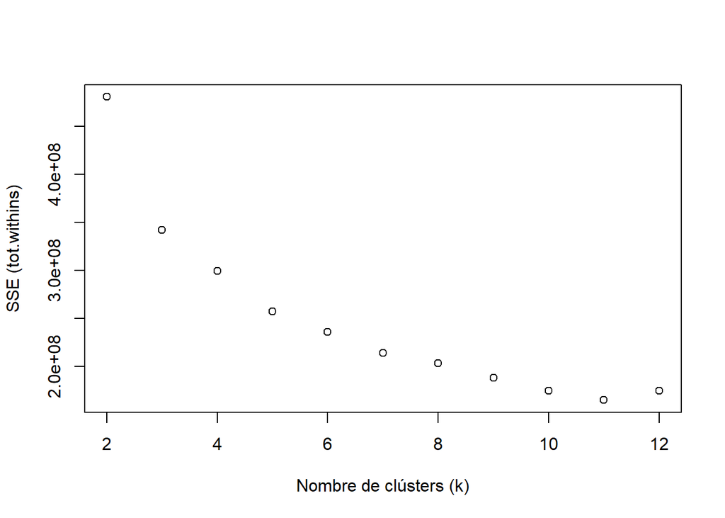

```r
# Gràfic del colze

plot(2:12,SSE[2:12], xlab="Nombre de clústers (k)", ylab="SSE (tot.withins)")
```

Sembla que sigui a partir del 10 que s’estabilitza, però al no poder tenir en compte aquesta observació perquè l’algoritme no ha convergit, ens quedem amb k=8

```r
daily_cluster<-select(daily, energy_sum,temperatureMax,temperatureMin, dewPoint, sunsetTimeHour,  humidity, month, weekday)
```

```r
SSE <- rep(0,10)
fit_kmeans_2 <- kmeans(daily_cluster, 2)
SSE[2]<-fit_kmeans_2$tot.withinss
fit_kmeans_3 <- kmeans(daily_cluster, 3)
SSE[3]<-fit_kmeans_3$tot.withinss

fit_kmeans_4 <- kmeans(daily_cluster, 4)
SSE[4]<-fit_kmeans_4$tot.withinss

fit_kmeans_5 <- kmeans(daily_cluster, 5)
SSE[5]<-fit_kmeans_5$tot.withinss

fit_kmeans_6 <- kmeans(daily_cluster, 6)
SSE[6]<-fit_kmeans_6$tot.withinss

fit_kmeans_7 <- kmeans(daily_cluster, 7)
SSE[7]<-fit_kmeans_7$tot.withinss

fit_kmeans_8 <- kmeans(daily_cluster, 8)
SSE[8]<-fit_kmeans_8$tot.withinss

fit_kmeans_9 <- kmeans(daily_cluster, 9)
SSE[9]<-fit_kmeans_9$tot.withinss

fit_kmeans_10 <- kmeans(daily_cluster, 10)
SSE[10]<-fit_kmeans_10$tot.withinss
```

En k=5 no convergeix.

```r
fit_kmeans_11 <- kmeans(daily_cluster, 11)
SSE[11]<-fit_kmeans_11$tot.withinss

fit_kmeans_12 <- kmeans(daily_cluster, 12)
SSE[12]<-fit_kmeans_12$tot.withinss
```

En k=12 no convergeix

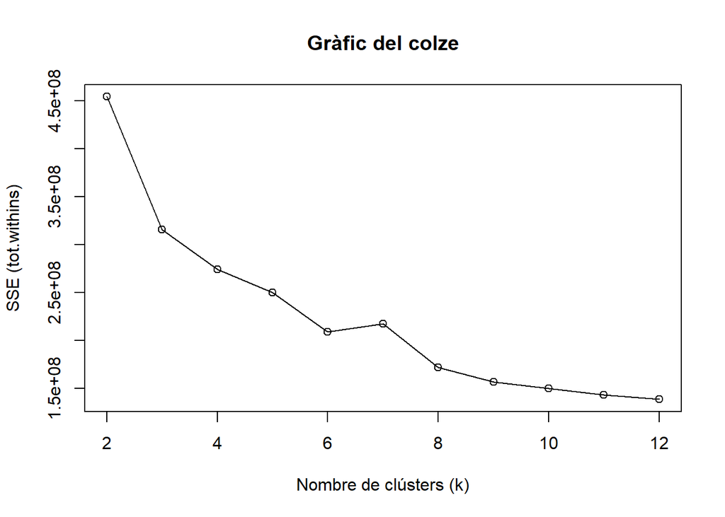

```r
# Gràfic del colze

plot(2:12,SSE[2:12], xlab="Nombre de clústers (k)", ylab="SSE (tot.withins)", type="o", main="Gràfic del colze")
```

Veiem que de 2 a 3 baixa en picat l’error, tot i que sembla que sigui a partir de k=9 on s’estabilitza i l’error quasi no varia.

```r
fit_kmeans_9 <- kmeans(daily_cluster, 9)
y_cluster9 <- fit_kmeans_9$cluster
```

```r
#Afegim a daily la variable de y_cluster per veure quines caracteristiques té cadascun dels 9 grups


daily$cluster_9<- y_cluster9
```

```r
daily$cluster_9<- as.factor(daily$cluster_9)

summary(daily$cluster_9)
```

```
##      1      2      3      4      5      6      7      8      9
##  41823 578083 585221 345627 257218 482525 478418 426498 321589
```

```r
summary(daily$Acorn_grouped[daily$cluster_9==1])
```

```
##   Adversity    Affluent Comfortable
##        3851       31368        6604
```

```r
summary(daily$Acorn_grouped[daily$cluster_9==2])
```

```
##   Adversity    Affluent Comfortable
##      202092      218264      157727
```

```r
summary(daily$Acorn_grouped[daily$cluster_9==3])
```

```
##   Adversity    Affluent Comfortable
##      209411      222684      153126
```

```r
summary(daily$Acorn_grouped[daily$cluster_9==4])
```

```
##   Adversity    Affluent Comfortable
##      122086      126971       96570
```

```r
summary(daily$Acorn_grouped[daily$cluster_9==5])
```

```
##   Adversity    Affluent Comfortable
##       56722      138337       62159
```

```r
summary(daily$Acorn_grouped[daily$cluster_9==6])
```

```
##   Adversity    Affluent Comfortable
##      171833      174855      135837
```

```r
summary(daily$Acorn_grouped[daily$cluster_9==7])
```

```
##   Adversity    Affluent Comfortable
##      173707      179239      125472
```

```r
summary(daily$Acorn_grouped[daily$cluster_9==8])
```

```
##   Adversity    Affluent Comfortable
##      146400      165531      114567
```

```r
summary(daily$Acorn_grouped[daily$cluster_9==9])
```

```
##   Adversity    Affluent Comfortable
##       80897      153966       86726
```

```r
summary(daily$stdorToU[daily$cluster_9==1])
```

```
##   Std   ToU
## 36195  5628
```

```r
summary(daily$stdorToU[daily$cluster_9==2])
```

```
##    Std    ToU
## 459704 118379
```

```r
summary(daily$stdorToU[daily$cluster_9==3])
```

```
##    Std    ToU
## 463235 121986
```

```r
summary(daily$stdorToU[daily$cluster_9==4])
```

```
##    Std    ToU
## 274072  71555
```

```r
summary(daily$stdorToU[daily$cluster_9==5])
```

```
##    Std    ToU
## 212765  44453
```

```r
summary(daily$stdorToU[daily$cluster_9==6])
```

```
##    Std    ToU
## 382479 100046
```

```r
summary(daily$cluster_9)
```

```
##      1      2      3      4      5      6      7      8      9
##  41823 578083 585221 345627 257218 482525 478418 426498 321589
```

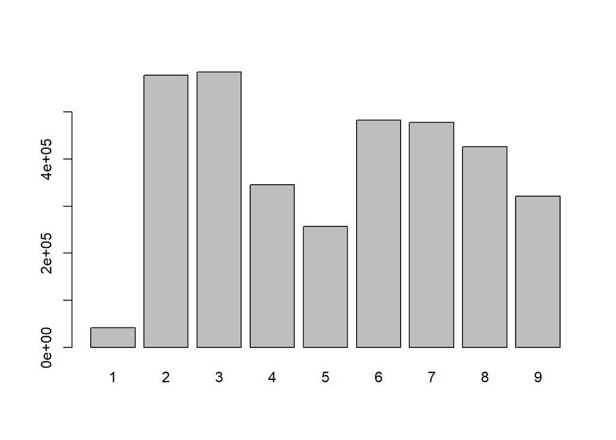

```r
barplot(summary(daily$cluster_9))
```

```r
#boxplot(daily$cluster_9,daily$Acorn_grouped)
```

```r
#hist(daily$cluster9)
```

```r
#clusplot(daily_cluster, y_cluster2, color=TRUE, shade=TRUE, labels=2, lines=0)
```

#Regles associació

```r
str(daily)
```

```
## 'data.frame':    3517002 obs. of  52 variables:
##  $ LCLid                      : chr  "MAC000152" "MAC000153" "MAC000156" "MAC000147" ...
##  $ date                       : Date, format: "2011-11-23" "2011-11-23" ...
##  $ energy_median              : num  0.172 0.676 0.275 0.075 0.174 ...
##  $ energy_mean                : num  0.249 0.904 0.296 0.108 0.252 ...
##  $ energy_max                 : num  0.798 2.407 0.512 0.315 0.999 ...
##  $ energy_count               : int  24 24 22 28 23 30 28 28 22 28 ...
##  $ energy_sum                 : num  5.97 21.7 6.52 3.04 5.8 ...
##  $ energy_min                 : num  0.055 0.261 0.162 0.033 0.098 0.094 0.008 0 0.11 0.059 ...
##  $ holidayType                : Factor w/ 10 levels "Boxing Day","Christmas Day",..: 7 7 7 7 7 7 7 7 7 7 ...
##  $ isHoliday                  : Factor w/ 2 levels "FALSE","TRUE": 1 1 1 1 1 1 1 1 1 1 ...
##  $ season                     : Factor w/ 4 levels "autumn","spring",..: 1 1 1 1 1 1 1 1 1 1 ...
##  $ stdorToU                   : Factor w/ 2 levels "Std","ToU": 1 1 1 2 1 1 1 1 1 1 ...
##  $ Acorn                      : Factor w/ 18 levels "ACORN-A","ACORN-B",..: 5 5 6 6 17 6 6 6 4 5 ...
##  $ Acorn_grouped              : Factor w/ 3 levels "Adversity","Affluent",..: 2 2 3 3 1 3 3 3 2 2 ...
```

[output cut: 38 more lines]

```r
#Creem dataset on només hi tinguem factors, que llavors binaritzarem:
 library(dplyr)
daily_factor<-select(daily, energy_sum, season, Acorn, month, weekday, tempMaxFactor , sunsetTimeHour, stdorToU, icon, isHoliday)
```

```r
summary(daily_factor$energy_sum)
```

```
##    Min. 1st Qu.  Median    Mean 3rd Qu.    Max.
##   0.000   4.682   7.816  10.127  12.572 332.556
```

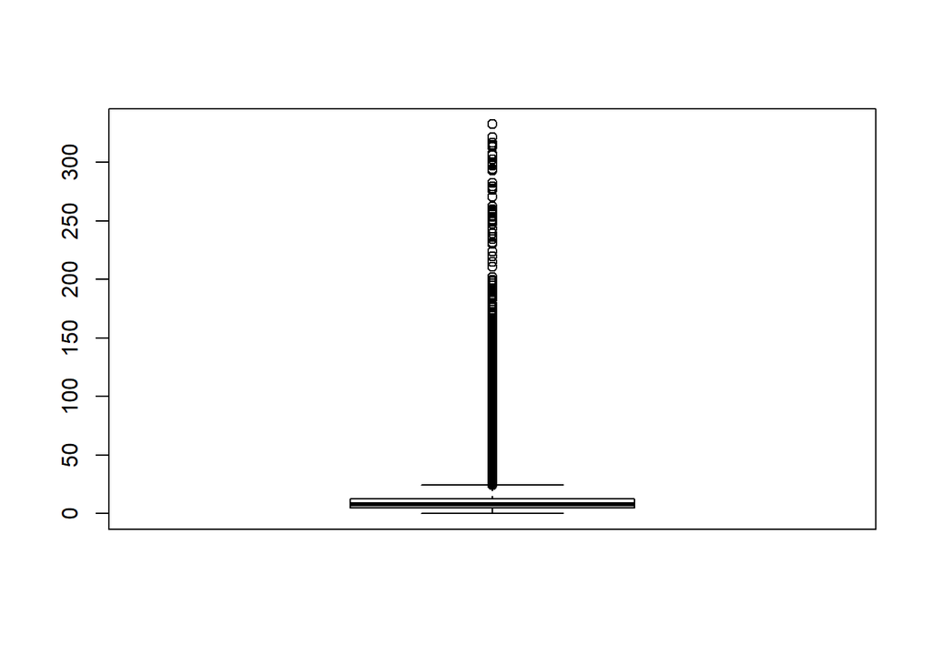

```r
boxplot(daily_factor$energy_sum)
```

```r
daily_factor$energy_sum_factor[daily_factor$energy_sum<333]<-"Molt alt"
daily_factor$energy_sum_factor[daily_factor$energy_sum<200]<-"Alt"
daily_factor$energy_sum_factor[daily_factor$energy_sum<15]<-"Normal"
daily_factor$energy_sum_factor[daily_factor$energy_sum<8]<-"Baix"
daily_factor$energy_sum_factor[daily_factor$energy_sum<4]<-"Molt baix"

daily_factor$energy_sum_factor<- as.factor(daily_factor$energy_sum_factor)

daily_factor$isHoliday<- as.factor(daily_factor$isHoliday)
daily_factor$month<- as.factor(daily_factor$month)
daily_factor$weekday<- as.factor(daily_factor$weekday)
daily_factor$sunsetTimeHour<- as.factor(daily_factor$sunsetTimeHour)

str(daily_factor)
```

```
## 'data.frame':    3517002 obs. of  11 variables:
##  $ energy_sum       : num  5.97 21.7 6.52 3.04 5.8 ...
##  $ season           : Factor w/ 4 levels "autumn","spring",..: 1 1 1 1 1 1 1 1 1 1 ...
##  $ Acorn            : Factor w/ 18 levels "ACORN-A","ACORN-B",..: 5 5 6 6 17 6 6 6 4 5 ...
##  $ month            : Factor w/ 12 levels "1","2","3","4",..: 11 11 11 11 11 11 11 11 11 11 ...
##  $ weekday          : Factor w/ 7 levels "1","2","3","4",..: 3 3 3 3 3 3 3 3 3 3 ...
##  $ tempMaxFactor    : Factor w/ 5 levels "Alta","Baixa",..: 2 2 2 2 2 2 2 2 2 2 ...
##  $ sunsetTimeHour   : Factor w/ 6 levels "1","2","3","4",..: 2 2 2 2 2 2 2 2 2 2 ...
##  $ stdorToU         : Factor w/ 2 levels "Std","ToU": 1 1 1 2 1 1 1 1 1 1 ...
##  $ icon             : Factor w/ 6 levels "clear-day","cloudy",..: 3 3 3 3 3 3 3 3 3 3 ...
##  $ isHoliday        : Factor w/ 2 levels "FALSE","TRUE": 1 1 1 1 1 1 1 1 1 1 ...
##  $ energy_sum_factor: Factor w/ 5 levels "Alt","Baix","Molt alt",..: 2 1 2 4 2 5 4 4 5 5 ...
```

```r
#Eliminem energy_sum numeric

daily_factor<-select(daily_factor,-energy_sum)
```

```r
library(arules)
#Binaritzem
daily_bin<-as(daily_factor,"transactions")
```

```r
#Regles

rules<-apriori(daily_bin)
```

```
## Apriori
##
## Parameter specification:
##  confidence minval smax arem  aval originalSupport maxtime support minlen
##         0.8    0.1    1 none FALSE            TRUE       5     0.1      1
##  maxlen target   ext
##      10  rules FALSE
##
## Algorithmic control:
##  filter tree heap memopt load sort verbose
##     0.1 TRUE TRUE  FALSE TRUE    2    TRUE
##
## Absolute minimum support count: 351700
##
## set item appearances ...[0 item(s)] done [0.00s].
## set transactions ...[67 item(s), 3517002 transaction(s)] done [1.57s].
## sorting and recoding items ... [32 item(s)] done [0.14s].
## creating transaction tree ... done [2.18s].
## checking subsets of size 1 2 3 4 5 done [0.01s].
## writing ... [172 rule(s)] done [0.00s].
## creating S4 object  ... done [0.20s].
```

```r
summary(rules)
```

```
## set of 172 rules
##
## rule length distribution (lhs + rhs):sizes
##  1  2  3  4  5
##  1 42 90 36  3
##
##    Min. 1st Qu.  Median    Mean 3rd Qu.    Max.
##   1.000   2.750   3.000   2.988   3.000   5.000
##
## summary of quality measures:
##     support         confidence          lift            count
##  Min.   :0.1006   Min.   :0.8000   Min.   :0.9678   Min.   : 353744
##  1st Qu.:0.1153   1st Qu.:0.9346   1st Qu.:0.9966   1st Qu.: 405594
##  Median :0.1395   Median :0.9700   Median :1.0018   Median : 490604
##  Mean   :0.1694   Mean   :0.9427   Mean   :1.1429   Mean   : 595840
##  3rd Qu.:0.1848   3rd Qu.:0.9791   3rd Qu.:1.0235   3rd Qu.: 650092
##  Max.   :0.9771   Max.   :1.0000   Max.   :3.4960   Max.   :3436372
##
## mining info:
##       data ntransactions support confidence
##  daily_bin       3517002     0.1        0.8
```

```r
rules.sorted<-sort(rules, by=c("confidence","support"))
inspect(rules.sorted)
```

```
##       lhs                              rhs                        support confidence      lift   count
## [1]   {season=autumn}               => {isHoliday=FALSE}        0.2718648  1.0000000 1.0234637  956149
## [2]   {season=autumn,
##        stdorToU=Std}                => {isHoliday=FALSE}        0.2169103  1.0000000 1.0234637  762874
## [3]   {season=autumn,
##        icon=partly-cloudy-day}      => {isHoliday=FALSE}        0.1824224  1.0000000 1.0234637  641580
## [4]   {sunsetTimeHour=3}            => {isHoliday=FALSE}        0.1694998  1.0000000 1.0234637  596131
## [5]   {season=autumn,
##        stdorToU=Std,
##        icon=partly-cloudy-day}      => {isHoliday=FALSE}        0.1455646  1.0000000 1.0234637  511951
## [6]   {season=autumn,
##        tempMaxFactor=Baixa}         => {isHoliday=FALSE}        0.1419976  1.0000000 1.0234637  499406
## [7]   {weekday=6}                   => {isHoliday=FALSE}        0.1419573  1.0000000 1.0234637  499264
## [8]   {sunsetTimeHour=3,
##        stdorToU=Std}                => {isHoliday=FALSE}        0.1354785  1.0000000 1.0234637  476478
## [9]   {season=autumn,
##        tempMaxFactor=Normal}        => {isHoliday=FALSE}        0.1251520  1.0000000 1.0234637  440160
## [10]  {sunsetTimeHour=3,
##        icon=partly-cloudy-day}      => {isHoliday=FALSE}        0.1195242  1.0000000 1.0234637  420367
## [11]  {season=autumn,
##        sunsetTimeHour=2}            => {isHoliday=FALSE}        0.1185774  1.0000000 1.0234637  417037
## [12]  {weekday=6,
##        stdorToU=Std}                => {isHoliday=FALSE}        0.1134094  1.0000000 1.0234637  398861
## [13]  {season=autumn,
##        tempMaxFactor=Baixa,
##        stdorToU=Std}                => {isHoliday=FALSE}        0.1132803  1.0000000 1.0234637  398407
## [14]  {weekday=6,
##        icon=partly-cloudy-day}      => {isHoliday=FALSE}        0.1079610  1.0000000 1.0234637  379699
## [15]  {weekday=7}                   => {isHoliday=FALSE}        0.1432459  0.9953413 1.0186957  503796
## [16]  {weekday=7,
##        stdorToU=Std}                => {isHoliday=FALSE}        0.1144375  0.9953088 1.0186624  402477
## [17]  {weekday=7,
##        icon=partly-cloudy-day}      => {isHoliday=FALSE}        0.1011387  0.9934146 1.0167237  355705
## [18]  {weekday=4,
##        icon=partly-cloudy-day}      => {isHoliday=FALSE}        0.1038646  0.9882372 1.0114249  365292
## [19]  {sunsetTimeHour=5}            => {isHoliday=FALSE}        0.1742820  0.9877401 1.0109161  612950
## [20]  {sunsetTimeHour=5,
##        stdorToU=Std}                => {isHoliday=FALSE}        0.1391427  0.9877202 1.0108958  489365
## [21]  {sunsetTimeHour=5,
##        icon=partly-cloudy-day}      => {isHoliday=FALSE}        0.1509158  0.9858687 1.0090008  530771
```

[output cut: 289 more lines]

```
##        icon=partly-cloudy-day,
##        isHoliday=FALSE}             => {stdorToU=Std}           0.1210190  0.8002813 1.0017482  425624
## [166] {season=spring,
##        icon=partly-cloudy-day}      => {stdorToU=Std}           0.1263781  0.8002708 1.0017351  444472
## [167] {season=winter,
##        icon=partly-cloudy-day,
##        isHoliday=FALSE}             => {stdorToU=Std}           0.1154981  0.8002218 1.0016738  406207
## [168] {season=winter,
##        icon=partly-cloudy-day}      => {stdorToU=Std}           0.1206485  0.8002101 1.0016591  424321
## [169] {season=winter,
##        isHoliday=FALSE}             => {stdorToU=Std}           0.1950704  0.8001043 1.0015266  686063
## [170] {isHoliday=FALSE,
##        energy_sum_factor=Normal}    => {stdorToU=Std}           0.2426931  0.8000990 1.0015200  853552
## [171] {energy_sum_factor=Normal}    => {stdorToU=Std}           0.2480564  0.8000658 1.0014785  872415
## [172] {season=winter}               => {stdorToU=Std}           0.2036840  0.8000270 1.0014299  716357
```